# Data Exploration, GoBike - San Francisco Bay

## Introduction

> Today I'm going to analyze a dataset of a bike-sharing company which includes the duration of riding the bike, some informations about the bike user, start and end stations. The location is the San Francisco Bay area.

## Preliminary Wrangling

```python
# import all packages and set plots to be embedded inline
import numpy as np
import pandas as pd
import matplotlib.pyplot as plt
import seaborn as sb

%matplotlib inline
from pandas.api.types import CategoricalDtype
sb.set_style('darkgrid')
base_color = sb.color_palette()[0]
```

```python
bike = pd.read_csv('SanFrancisco-bike.csv')
```

```python
print(bike.shape)
print(bike.dtypes)
bike.head()
```

```
(183412, 16)
duration_sec                 int64
start_time                  object
end_time                    object
start_station_id           float64
start_station_name          object
start_station_latitude     float64
start_station_longitude    float64
end_station_id             float64
end_station_name            object
end_station_latitude       float64
end_station_longitude      float64
bike_id                      int64
user_type                   object
member_birth_year          float64
member_gender               object
bike_share_for_all_trip     object
dtype: object
```

|  | duration_sec | start_time | end_time | start_station_id | start_station_name | start_station_latitude | start_station_longitude | end_station_id | end_station_name | end_station_latitude | end_station_longitude | bike_id | user_type | member_birth_year | member_gender | bike_share_for_all_trip |
| --- | --- | --- | --- | --- | --- | --- | --- | --- | --- | --- | --- | --- | --- | --- | --- | --- |
| 0 | 52185 | 2019-02-28 17:32:10.1450 | 2019-03-01 08:01:55.9750 | 21.0 | Montgomery St BART Station (Market St at 2nd St) | 37.789625 | -122.400811 | 13.0 | Commercial St at Montgomery St | 37.794231 | -122.402923 | 4902 | Customer | 1984.0 | Male | No |
| 1 | 42521 | 2019-02-28 18:53:21.7890 | 2019-03-01 06:42:03.0560 | 23.0 | The Embarcadero at Steuart St | 37.791464 | -122.391034 | 81.0 | Berry St at 4th St | 37.775880 | -122.393170 | 2535 | Customer | NaN | NaN | No |
| 2 | 61854 | 2019-02-28 12:13:13.2180 | 2019-03-01 05:24:08.1460 | 86.0 | Market St at Dolores St | 37.769305 | -122.426826 | 3.0 | Powell St BART Station (Market St at 4th St) | 37.786375 | -122.404904 | 5905 | Customer | 1972.0 | Male | No |
| 3 | 36490 | 2019-02-28 17:54:26.0100 | 2019-03-01 04:02:36.8420 | 375.0 | Grove St at Masonic Ave | 37.774836 | -122.446546 | 70.0 | Central Ave at Fell St | 37.773311 | -122.444293 | 6638 | Subscriber | 1989.0 | Other | No |
| 4 | 1585 | 2019-02-28 23:54:18.5490 | 2019-03-01 00:20:44.0740 | 7.0 | Frank H Ogawa Plaza | 37.804562 | -122.271738 | 222.0 | 10th Ave at E 15th St | 37.792714 | -122.248780 | 4898 | Subscriber | 1974.0 | Male | Yes |

```python
bike.describe()
```

|  | duration_sec | start_station_id | start_station_latitude | start_station_longitude | end_station_id | end_station_latitude | end_station_longitude | bike_id | member_birth_year |
| --- | --- | --- | --- | --- | --- | --- | --- | --- | --- |
| count | 183412.000000 | 183215.000000 | 183412.000000 | 183412.000000 | 183215.000000 | 183412.000000 | 183412.000000 | 183412.000000 | 175147.000000 |
| mean | 726.078435 | 138.590427 | 37.771223 | -122.352664 | 136.249123 | 37.771427 | -122.352250 | 4472.906375 | 1984.806437 |
| std | 1794.389780 | 111.778864 | 0.099581 | 0.117097 | 111.515131 | 0.099490 | 0.116673 | 1664.383394 | 10.116689 |
| min | 61.000000 | 3.000000 | 37.317298 | -122.453704 | 3.000000 | 37.317298 | -122.453704 | 11.000000 | 1878.000000 |
| 25% | 325.000000 | 47.000000 | 37.770083 | -122.412408 | 44.000000 | 37.770407 | -122.411726 | 3777.000000 | 1980.000000 |
| 50% | 514.000000 | 104.000000 | 37.780760 | -122.398285 | 100.000000 | 37.781010 | -122.398279 | 4958.000000 | 1987.000000 |
| 75% | 796.000000 | 239.000000 | 37.797280 | -122.286533 | 235.000000 | 37.797320 | -122.288045 | 5502.000000 | 1992.000000 |
| max | 85444.000000 | 398.000000 | 37.880222 | -121.874119 | 398.000000 | 37.880222 | -121.874119 | 6645.000000 | 2001.000000 |

```python
bike.info()
```

```
<class 'pandas.core.frame.DataFrame'>
RangeIndex: 183412 entries, 0 to 183411
Data columns (total 16 columns):
duration_sec               183412 non-null int64
start_time                 183412 non-null object
end_time                   183412 non-null object
start_station_id           183215 non-null float64
start_station_name         183215 non-null object
start_station_latitude     183412 non-null float64
start_station_longitude    183412 non-null float64
end_station_id             183215 non-null float64
end_station_name           183215 non-null object
end_station_latitude       183412 non-null float64
end_station_longitude      183412 non-null float64
bike_id                    183412 non-null int64
user_type                  183412 non-null object
member_birth_year          175147 non-null float64
member_gender              175147 non-null object
bike_share_for_all_trip    183412 non-null object
dtypes: float64(7), int64(2), object(7)
memory usage: 22.4+ MB
```

Bike has 183'412 rows. How many missing values are there and in which columns?

- start_station_id -> 197
- start_station_name -> 197
- end_station_id -> 197
- end_station_name -> 197
- member_birth_year -> 8'265
- member_gender -> 8'265

```python
# checking if all start_station_latitude values are the same for Montgomery St BART Station (Market St at 2nd St)
bike[bike['start_station_name'] == "Montgomery St BART Station (Market St at 2nd St)"]
```

|  | duration_sec | start_time | end_time | start_station_id | start_station_name | start_station_latitude | start_station_longitude | end_station_id | end_station_name | end_station_latitude | end_station_longitude | bike_id | user_type | member_birth_year | member_gender | bike_share_for_all_trip |
| --- | --- | --- | --- | --- | --- | --- | --- | --- | --- | --- | --- | --- | --- | --- | --- | --- |
| 0 | 52185 | 2019-02-28 17:32:10.1450 | 2019-03-01 08:01:55.9750 | 21.0 | Montgomery St BART Station (Market St at 2nd St) | 37.789625 | -122.400811 | 13.0 | Commercial St at Montgomery St | 37.794231 | -122.402923 | 4902 | Customer | 1984.0 | Male | No |
| 63 | 239 | 2019-02-28 23:28:42.7090 | 2019-02-28 23:32:41.7690 | 21.0 | Montgomery St BART Station (Market St at 2nd St) | 37.789625 | -122.400811 | 343.0 | Bryant St at 2nd St | 37.783172 | -122.393572 | 5731 | Subscriber | 1986.0 | Male | No |
| 477 | 430 | 2019-02-28 21:17:07.9190 | 2019-02-28 21:24:18.4030 | 21.0 | Montgomery St BART Station (Market St at 2nd St) | 37.789625 | -122.400811 | 16.0 | Steuart St at Market St | 37.794130 | -122.394430 | 6210 | Subscriber | 1986.0 | Male | No |
| 486 | 753 | 2019-02-28 21:10:17.6620 | 2019-02-28 21:22:51.1550 | 21.0 | Montgomery St BART Station (Market St at 2nd St) | 37.789625 | -122.400811 | 76.0 | McCoppin St at Valencia St | 37.771662 | -122.422423 | 6419 | Subscriber | 1992.0 | Female | No |
| 505 | 352 | 2019-02-28 21:14:29.8970 | 2019-02-28 21:20:22.7000 | 21.0 | Montgomery St BART Station (Market St at 2nd St) | 37.789625 | -122.400811 | 27.0 | Beale St at Harrison St | 37.788059 | -122.391865 | 5108 | Subscriber | 1958.0 | Male | No |
| 519 | 461 | 2019-02-28 21:10:42.3530 | 2019-02-28 21:18:23.5180 | 21.0 | Montgomery St BART Station (Market St at 2nd St) | 37.789625 | -122.400811 | 30.0 | San Francisco Caltrain (Townsend St at 4th St) | 37.776598 | -122.395282 | 5299 | Subscriber | 1979.0 | Male | No |
| 526 | 335 | 2019-02-28 21:11:26.9780 | 2019-02-28 21:17:02.3870 | 21.0 | Montgomery St BART Station (Market St at 2nd St) | 37.789625 | -122.400811 | 10.0 | Washington St at Kearny St | 37.795393 | -122.404770 | 6168 | Subscriber | 1990.0 | Male | No |
| 727 | 377 | 2019-02-28 20:36:41.0570 | 2019-02-28 20:42:58.5860 | 21.0 | Montgomery St BART Station (Market St at 2nd St) | 37.789625 | -122.400811 | 343.0 | Bryant St at 2nd St | 37.783172 | -122.393572 | 1113 | Subscriber | 1992.0 | Female | No |
| 768 | 472 | 2019-02-28 20:27:34.9640 | 2019-02-28 20:35:26.9640 | 21.0 | Montgomery St BART Station (Market St at 2nd St) | 37.789625 | -122.400811 | 28.0 | The Embarcadero at Bryant St | 37.787168 | -122.388098 | 2032 | Subscriber | NaN | NaN | No |
| 848 | 314 | 2019-02-28 20:16:27.9470 | 2019-02-28 20:21:42.4210 | 21.0 | Montgomery St BART Station (Market St at 2nd St) | 37.789625 | -122.400811 | 5.0 | Powell St BART Station (Market St at 5th St) | 37.783899 | -122.408445 | 1458 | Subscriber | NaN | NaN | No |
| 860 | 518 | 2019-02-28 20:12:01.2300 | 2019-02-28 20:20:39.9550 | 21.0 | Montgomery St BART Station (Market St at 2nd St) | 37.789625 | -122.400811 | 67.0 | San Francisco Caltrain Station 2 (Townsend St... | 37.776639 | -122.395526 | 817 | Subscriber | 1989.0 | Male | No |
| 888 | 649 | 2019-02-28 20:07:11.1700 | 2019-02-28 20:18:01.0460 | 21.0 | Montgomery St BART Station (Market St at 2nd St) | 37.789625 | -122.400811 | 58.0 | Market St at 10th St | 37.776619 | -122.417385 | 789 | Subscriber | 1999.0 | Female | No |
| 971 | 1059 | 2019-02-28 19:48:48.1870 | 2019-02-28 20:06:27.2090 | 21.0 | Montgomery St BART Station (Market St at 2nd St) | 37.789625 | -122.400811 | 56.0 | Koshland Park | 37.773414 | -122.427317 | 6192 | Subscriber | 1997.0 | Female | No |
| 973 | 593 | 2019-02-28 19:56:14.6130 | 2019-02-28 20:06:08.3200 | 21.0 | Montgomery St BART Station (Market St at 2nd St) | 37.789625 | -122.400811 | 28.0 | The Embarcadero at Bryant St | 37.787168 | -122.388098 | 2107 | Subscriber | 1990.0 | Male | No |
| 991 | 248 | 2019-02-28 19:59:19.4360 | 2019-02-28 20:03:28.3930 | 21.0 | Montgomery St BART Station (Market St at 2nd St) | 37.789625 | -122.400811 | 16.0 | Steuart St at Market St | 37.794130 | -122.394430 | 1547 | Subscriber | 1968.0 | Male | No |
| 995 | 866 | 2019-02-28 19:48:35.0570 | 2019-02-28 20:03:01.3350 | 21.0 | Montgomery St BART Station (Market St at 2nd St) | 37.789625 | -122.400811 | 74.0 | Laguna St at Hayes St | 37.776435 | -122.426244 | 5525 | Subscriber | NaN | NaN | No |
| 999 | 676 | 2019-02-28 19:51:31.5440 | 2019-02-28 20:02:48.4540 | 21.0 | Montgomery St BART Station (Market St at 2nd St) | 37.789625 | -122.400811 | 92.0 | Mission Bay Kids Park | 37.772301 | -122.393028 | 3642 | Subscriber | 1989.0 | Female | No |
| 1139 | 2345 | 2019-02-28 19:07:21.1840 | 2019-02-28 19:46:27.0490 | 21.0 | Montgomery St BART Station (Market St at 2nd St) | 37.789625 | -122.400811 | 66.0 | 3rd St at Townsend St | 37.778742 | -122.392741 | 5870 | Customer | 1980.0 | Male | No |
| 1176 | 1484 | 2019-02-28 19:17:32.4590 | 2019-02-28 19:42:17.3290 | 21.0 | Montgomery St BART Station (Market St at 2nd St) | 37.789625 | -122.400811 | 134.0 | Valencia St at 24th St | 37.752428 | -122.420628 | 2330 | Subscriber | 1986.0 | Other | No |
| 1219 | 1408 | 2019-02-28 19:13:35.9250 | 2019-02-28 19:37:04.1930 | 21.0 | Montgomery St BART Station (Market St at 2nd St) | 37.789625 | -122.400811 | 119.0 | 18th St at Noe St | 37.761047 | -122.432642 | 6111 | Subscriber | 1991.0 | Male | No |
| 1272 | 970 | 2019-02-28 19:16:45.6420 | 2019-02-28 19:32:56.2940 | 21.0 | Montgomery St BART Station (Market St at 2nd St) | 37.789625 | -122.400811 | 115.0 | Jackson Playground | 37.765026 | -122.398773 | 6234 | Subscriber | 1974.0 | Male | No |
| 1314 | 1087 | 2019-02-28 19:10:02.5060 | 2019-02-28 19:28:09.6780 | 21.0 | Montgomery St BART Station (Market St at 2nd St) | 37.789625 | -122.400811 | 53.0 | Grove St at Divisadero | 37.775946 | -122.437777 | 5824 | Subscriber | 1983.0 | Male | No |
| 1319 | 1067 | 2019-02-28 19:10:05.2880 | 2019-02-28 19:27:52.7470 | 21.0 | Montgomery St BART Station (Market St at 2nd St) | 37.789625 | -122.400811 | 53.0 | Grove St at Divisadero | 37.775946 | -122.437777 | 6120 | Subscriber | 1991.0 | Male | No |
| 1326 | 857 | 2019-02-28 19:12:40.1000 | 2019-02-28 19:26:57.5900 | 21.0 | Montgomery St BART Station (Market St at 2nd St) | 37.789625 | -122.400811 | 4.0 | Cyril Magnin St at Ellis St | 37.785881 | -122.408915 | 4751 | Subscriber | 1999.0 | Male | No |
| 1328 | 826 | 2019-02-28 19:13:01.0140 | 2019-02-28 19:26:47.3820 | 21.0 | Montgomery St BART Station (Market St at 2nd St) | 37.789625 | -122.400811 | 4.0 | Cyril Magnin St at Ellis St | 37.785881 | -122.408915 | 6343 | Subscriber | 1998.0 | Female | No |
| 1371 | 638 | 2019-02-28 19:12:34.8730 | 2019-02-28 19:23:13.0070 | 21.0 | Montgomery St BART Station (Market St at 2nd St) | 37.789625 | -122.400811 | 6.0 | The Embarcadero at Sansome St | 37.804770 | -122.403234 | 3066 | Subscriber | 1974.0 | Male | No |
| 1501 | 1182 | 2019-02-28 18:51:05.7450 | 2019-02-28 19:10:48.0760 | 21.0 | Montgomery St BART Station (Market St at 2nd St) | 37.789625 | -122.400811 | 6.0 | The Embarcadero at Sansome St | 37.804770 | -122.403234 | 6070 | Customer | 1987.0 | Male | No |
| 1528 | 1008 | 2019-02-28 18:51:27.3770 | 2019-02-28 19:08:15.5510 | 21.0 | Montgomery St BART Station (Market St at 2nd St) | 37.789625 | -122.400811 | 129.0 | Harrison St at 20th St | 37.758862 | -122.412544 | 5568 | Customer | 1988.0 | Male | No |
| 1578 | 740 | 2019-02-28 18:52:00.2670 | 2019-02-28 19:04:20.7010 | 21.0 | Montgomery St BART Station (Market St at 2nd St) | 37.789625 | -122.400811 | 126.0 | Esprit Park | 37.761634 | -122.390648 | 6148 | Subscriber | 1984.0 | Male | No |
| 1689 | 658 | 2019-02-28 18:45:51.8930 | 2019-02-28 18:56:50.5260 | 21.0 | Montgomery St BART Station (Market St at 2nd St) | 37.789625 | -122.400811 | 42.0 | San Francisco City Hall (Polk St at Grove St) | 37.778650 | -122.418230 | 6101 | Subscriber | 1994.0 | Male | No |
| ... | ... | ... | ... | ... | ... | ... | ... | ... | ... | ... | ... | ... | ... | ... | ... | ... |
| 181086 | 380 | 2019-02-01 09:34:18.2740 | 2019-02-01 09:40:39.1510 | 21.0 | Montgomery St BART Station (Market St at 2nd St) | 37.789625 | -122.400811 | 323.0 | Broadway at Kearny | 37.798014 | -122.405950 | 5045 | Subscriber | 1969.0 | Female | No |
| 181104 | 352 | 2019-02-01 09:33:15.6450 | 2019-02-01 09:39:07.7990 | 21.0 | Montgomery St BART Station (Market St at 2nd St) | 37.789625 | -122.400811 | 323.0 | Broadway at Kearny | 37.798014 | -122.405950 | 4719 | Subscriber | 1985.0 | Male | No |
| 181140 | 420 | 2019-02-01 09:29:25.2180 | 2019-02-01 09:36:26.1290 | 21.0 | Montgomery St BART Station (Market St at 2nd St) | 37.789625 | -122.400811 | 6.0 | The Embarcadero at Sansome St | 37.804770 | -122.403234 | 5294 | Customer | 1992.0 | Female | No |
| 181226 | 432 | 2019-02-01 09:22:53.6790 | 2019-02-01 09:30:06.3370 | 21.0 | Montgomery St BART Station (Market St at 2nd St) | 37.789625 | -122.400811 | 50.0 | 2nd St at Townsend St | 37.780526 | -122.390288 | 5025 | Subscriber | 1970.0 | Male | No |
| 181233 | 775 | 2019-02-01 09:16:28.8510 | 2019-02-01 09:29:24.8440 | 21.0 | Montgomery St BART Station (Market St at 2nd St) | 37.789625 | -122.400811 | 58.0 | Market St at 10th St | 37.776619 | -122.417385 | 5305 | Subscriber | 1967.0 | Male | No |
| 181255 | 355 | 2019-02-01 09:22:16.0640 | 2019-02-01 09:28:12.0300 | 21.0 | Montgomery St BART Station (Market St at 2nd St) | 37.789625 | -122.400811 | 50.0 | 2nd St at Townsend St | 37.780526 | -122.390288 | 5425 | Subscriber | 1991.0 | Male | No |
| 181380 | 765 | 2019-02-01 09:09:20.5050 | 2019-02-01 09:22:05.8090 | 21.0 | Montgomery St BART Station (Market St at 2nd St) | 37.789625 | -122.400811 | 87.0 | Folsom St at 13th St | 37.769757 | -122.415674 | 5353 | Subscriber | 1987.0 | Male | No |
| 181412 | 412 | 2019-02-01 09:13:43.2000 | 2019-02-01 09:20:35.8770 | 21.0 | Montgomery St BART Station (Market St at 2nd St) | 37.789625 | -122.400811 | 343.0 | Bryant St at 2nd St | 37.783172 | -122.393572 | 5007 | Subscriber | 1977.0 | Male | No |
| 181505 | 255 | 2019-02-01 09:11:48.3390 | 2019-02-01 09:16:03.8060 | 21.0 | Montgomery St BART Station (Market St at 2nd St) | 37.789625 | -122.400811 | 16.0 | Steuart St at Market St | 37.794130 | -122.394430 | 4969 | Subscriber | 1980.0 | Female | No |
| 181517 | 326 | 2019-02-01 09:09:48.6390 | 2019-02-01 09:15:15.1250 | 21.0 | Montgomery St BART Station (Market St at 2nd St) | 37.789625 | -122.400811 | 343.0 | Bryant St at 2nd St | 37.783172 | -122.393572 | 5216 | Subscriber | NaN | NaN | No |
| 181544 | 593 | 2019-02-01 09:03:35.0060 | 2019-02-01 09:13:28.4670 | 21.0 | Montgomery St BART Station (Market St at 2nd St) | 37.789625 | -122.400811 | 81.0 | Berry St at 4th St | 37.775880 | -122.393170 | 5565 | Subscriber | 1987.0 | Male | No |
| 181590 | 484 | 2019-02-01 09:02:58.9700 | 2019-02-01 09:11:03.7180 | 21.0 | Montgomery St BART Station (Market St at 2nd St) | 37.789625 | -122.400811 | 50.0 | 2nd St at Townsend St | 37.780526 | -122.390288 | 1661 | Subscriber | 1975.0 | Male | No |
| 181598 | 412 | 2019-02-01 09:03:39.5640 | 2019-02-01 09:10:32.1410 | 21.0 | Montgomery St BART Station (Market St at 2nd St) | 37.789625 | -122.400811 | 9.0 | Broadway at Battery St | 37.798572 | -122.400869 | 5358 | Subscriber | 1987.0 | Male | No |
| 181622 | 289 | 2019-02-01 09:04:27.6590 | 2019-02-01 09:09:17.1690 | 21.0 | Montgomery St BART Station (Market St at 2nd St) | 37.789625 | -122.400811 | 37.0 | 2nd St at Folsom St | 37.785000 | -122.395936 | 200 | Subscriber | 1980.0 | Male | No |
| 181688 | 819 | 2019-02-01 08:52:13.0450 | 2019-02-01 09:05:52.8650 | 21.0 | Montgomery St BART Station (Market St at 2nd St) | 37.789625 | -122.400811 | 77.0 | 11th St at Natoma St | 37.773507 | -122.416040 | 5166 | Subscriber | 1971.0 | Male | No |
| 181727 | 296 | 2019-02-01 08:59:09.1390 | 2019-02-01 09:04:05.4380 | 21.0 | Montgomery St BART Station (Market St at 2nd St) | 37.789625 | -122.400811 | 50.0 | 2nd St at Townsend St | 37.780526 | -122.390288 | 5526 | Subscriber | 1987.0 | Male | No |
| 181774 | 524 | 2019-02-01 08:52:57.5300 | 2019-02-01 09:01:42.2060 | 21.0 | Montgomery St BART Station (Market St at 2nd St) | 37.789625 | -122.400811 | 81.0 | Berry St at 4th St | 37.775880 | -122.393170 | 4744 | Subscriber | 1990.0 | Male | No |
| 181807 | 296 | 2019-02-01 08:54:29.8290 | 2019-02-01 08:59:26.1040 | 21.0 | Montgomery St BART Station (Market St at 2nd St) | 37.789625 | -122.400811 | 36.0 | Folsom St at 3rd St | 37.783830 | -122.398870 | 4970 | Subscriber | 1979.0 | Male | No |
| 181824 | 300 | 2019-02-01 08:53:45.0240 | 2019-02-01 08:58:45.9070 | 21.0 | Montgomery St BART Station (Market St at 2nd St) | 37.789625 | -122.400811 | 343.0 | Bryant St at 2nd St | 37.783172 | -122.393572 | 4611 | Subscriber | 1973.0 | Male | No |
| 181987 | 474 | 2019-02-01 08:41:31.6000 | 2019-02-01 08:49:26.2840 | 21.0 | Montgomery St BART Station (Market St at 2nd St) | 37.789625 | -122.400811 | 49.0 | S Park St at 3rd St | 37.780760 | -122.394989 | 4626 | Subscriber | 1988.0 | Female | No |
| 182020 | 474 | 2019-02-01 08:39:53.6710 | 2019-02-01 08:47:48.3130 | 21.0 | Montgomery St BART Station (Market St at 2nd St) | 37.789625 | -122.400811 | 66.0 | 3rd St at Townsend St | 37.778742 | -122.392741 | 4942 | Subscriber | 1991.0 | Male | No |
| 182082 | 777 | 2019-02-01 08:31:38.6460 | 2019-02-01 08:44:35.7030 | 21.0 | Montgomery St BART Station (Market St at 2nd St) | 37.789625 | -122.400811 | 126.0 | Esprit Park | 37.761634 | -122.390648 | 5288 | Subscriber | 1991.0 | Male | No |
| 182559 | 318 | 2019-02-01 08:11:08.2190 | 2019-02-01 08:16:26.5650 | 21.0 | Montgomery St BART Station (Market St at 2nd St) | 37.789625 | -122.400811 | 49.0 | S Park St at 3rd St | 37.780760 | -122.394989 | 4850 | Subscriber | 1979.0 | Male | No |
| 182806 | 310 | 2019-02-01 07:49:41.3830 | 2019-02-01 07:54:51.7570 | 21.0 | Montgomery St BART Station (Market St at 2nd St) | 37.789625 | -122.400811 | 343.0 | Bryant St at 2nd St | 37.783172 | -122.393572 | 4611 | Subscriber | 1995.0 | Female | No |
| 182826 | 316 | 2019-02-01 07:47:52.8700 | 2019-02-01 07:53:09.4380 | 21.0 | Montgomery St BART Station (Market St at 2nd St) | 37.789625 | -122.400811 | 343.0 | Bryant St at 2nd St | 37.783172 | -122.393572 | 5543 | Subscriber | 1989.0 | Male | No |
| 182835 | 288 | 2019-02-01 07:46:43.2970 | 2019-02-01 07:51:32.1730 | 21.0 | Montgomery St BART Station (Market St at 2nd St) | 37.789625 | -122.400811 | 14.0 | Clay St at Battery St | 37.795001 | -122.399970 | 4600 | Subscriber | 1993.0 | Male | Yes |
| 182840 | 275 | 2019-02-01 07:46:34.8830 | 2019-02-01 07:51:10.7810 | 21.0 | Montgomery St BART Station (Market St at 2nd St) | 37.789625 | -122.400811 | 49.0 | S Park St at 3rd St | 37.780760 | -122.394989 | 5282 | Subscriber | 1982.0 | Male | No |
| 182999 | 469 | 2019-02-01 07:23:32.1360 | 2019-02-01 07:31:21.8380 | 21.0 | Montgomery St BART Station (Market St at 2nd St) | 37.789625 | -122.400811 | 81.0 | Berry St at 4th St | 37.775880 | -122.393170 | 1830 | Subscriber | 1980.0 | Male | No |
| 183192 | 143 | 2019-02-01 06:45:15.4270 | 2019-02-01 06:47:39.3800 | 21.0 | Montgomery St BART Station (Market St at 2nd St) | 37.789625 | -122.400811 | 25.0 | Howard St at 2nd St | 37.787522 | -122.397405 | 4737 | Subscriber | 1982.0 | Male | No |
| 183408 | 313 | 2019-02-01 00:05:34.7440 | 2019-02-01 00:10:48.5020 | 21.0 | Montgomery St BART Station (Market St at 2nd St) | 37.789625 | -122.400811 | 66.0 | 3rd St at Townsend St | 37.778742 | -122.392741 | 4960 | Subscriber | 1984.0 | Male | No |

2895 rows × 16 columns

Based on these two DataFrames I assume following:

- Stations and ID have the similar amount of missing values. I would say that the reason for this is that bike users did fetch nor return the bike at a station. I will go and check if there are duplicate longitudes in rows with missing values in stations and ID.
- Missing values in Birthday and gender happens to subscribers and costumers. If I plan to work with that I might have to delete these rows in that particular visualization. I can leave the rows in other charts.

### What is the structure of your dataset?

> Bike has 183'412 rows and 16 columns. Everything is an object or a float except the bike_id and duration_sec which are ints and which I have to convert into a string and a float. Depending on what I need to answer, I might have to change more things or nothing at all, which I doubt that I will be nothing :D.

### What is/are the main feature(s) of interest in your dataset?

> I'm interested in finding out more about the company's biker-users. Are there more women, men or others? Is there something to compare between costumers and subscribers - like who is using it more and longer? I would also like to dig into the duration and when do people tend to rent the bycles? Maybe I can find out if I have more users going to work with their bike than using it for their spare time.

### What features in the dataset do you think will help support your investigation into your feature(s) of interest?

> There are a lot of features which can help me answer my questions. Start end Endtime, combined with the duration time for example is the most valuable column. This can help me find out when are most of the people using the bikes. The provider might have to make sure to have enough bikes and certain times. Of course I need the user type, member birthday and member gender columns as well.

## Univariate Exploration

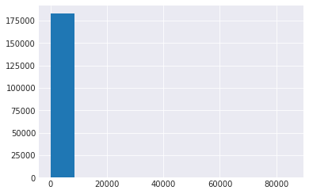

```python
# How does the distribution of duration look?
plt.hist(bike.duration_sec);
```

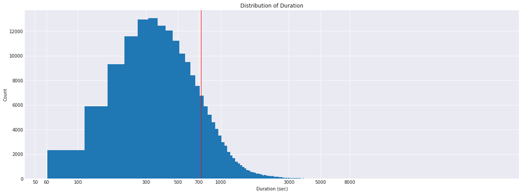

```python
plt.figure(figsize = [20, 7])

max_duration = bike.duration_sec.max()
min_duration = bike.duration_sec.min()
bins = np.arange(min_duration, max_duration + 10, 50)
plt.hist(data = bike, x = 'duration_sec', bins = bins)
plt.xscale('log')
ticks = [50, 60, 100, 300, 500, 700, 1000, 3000, 5000, 8000]
labels = ['{}'.format(v) for v in ticks]
plt.xticks(ticks, labels)
plt.axvline(bike.duration_sec.mean(), color = 'red', linewidth = 1)
plt.xlabel('Duration (sec)')
plt.ylabel('Count')
plt.title('Distribution of Duration');
```

We found out that the chart is unimodal. It's right skewed and the mean lies near 700 which means that people tend to rent the bike for circa 12 minutes. I don't believe that people can do 'sports' in just 12 minutes. Sporty people would have to use it for a way longer time than 12 minutes. 12 Minutes sound for me like going from place A to B fastly. I could try to find out if bycicles get rent more on the weekends than during the week. On the weekends most people tend to have days of. I'm not one of them for sure. For this I got to convert the date strings into datatime objects and create new columns day, month and year.

```python
# converting two columns from string dates int datetime
bike['start_time'] = bike['start_time'].astype('datetime64[ns]')
bike['end_time'] = bike['end_time'].astype('datetime64[ns]')
bike.info()
```

```
<class 'pandas.core.frame.DataFrame'>
RangeIndex: 183412 entries, 0 to 183411
Data columns (total 16 columns):
duration_sec               183412 non-null int64
start_time                 183412 non-null datetime64[ns]
end_time                   183412 non-null datetime64[ns]
start_station_id           183215 non-null float64
start_station_name         183215 non-null object
start_station_latitude     183412 non-null float64
start_station_longitude    183412 non-null float64
end_station_id             183215 non-null float64
end_station_name           183215 non-null object
end_station_latitude       183412 non-null float64
end_station_longitude      183412 non-null float64
bike_id                    183412 non-null int64
user_type                  183412 non-null object
member_birth_year          175147 non-null float64
member_gender              175147 non-null object
bike_share_for_all_trip    183412 non-null object
dtypes: datetime64[ns](2), float64(7), int64(2), object(5)
memory usage: 22.4+ MB
```

If I want to create day, month and year column, I have the problem that start and endtime could have different days, months and years. I might never know if somebody had a new years resolution of riding more bycicle and startet it on the 31. December before midnight. I will create 6 columns 3 for start and 3 for end column. After that I will compare them and look which ones have different years. I can delete the second year if I found 0 cases, where they differ. The same goes for months and days. I except to find differences in days but I will think about what to do with it, when I get there. Let's go.

```python
bike['start_year'] = bike['start_time'].dt.year
bike['start_month'] = bike['start_time'].dt.month
bike['start_day'] = bike['start_time'].dt.weekday_name
bike['end_year'] = bike['end_time'].dt.year
bike['end_month'] = bike['end_time'].dt.month
bike['end_day'] = bike['end_time'].dt.weekday_name
```

```python
bike['start_time_hour'] = bike['start_time'].dt.hour
```

```python
bike.head(1)
```

|  | duration_sec | start_time | end_time | start_station_id | start_station_name | start_station_latitude | start_station_longitude | end_station_id | end_station_name | end_station_latitude | ... | member_birth_year | member_gender | bike_share_for_all_trip | start_year | start_month | start_day | end_year | end_month | end_day | start_time_hour |
| --- | --- | --- | --- | --- | --- | --- | --- | --- | --- | --- | --- | --- | --- | --- | --- | --- | --- | --- | --- | --- | --- |
| 0 | 52185 | 2019-02-28 17:32:10.145 | 2019-03-01 08:01:55.975 | 21.0 | Montgomery St BART Station (Market St at 2nd St) | 37.789625 | -122.400811 | 13.0 | Commercial St at Montgomery St | 37.794231 | ... | 1984.0 | Male | No | 2019 | 2 | Thursday | 2019 | 3 | Friday | 17 |

1 rows × 23 columns

And here we got it already...first case of different day and month. I will still go and check for the differences.

```python
# checking for different years
bike[bike['start_year'] != bike['end_year']]
```

|  | duration_sec | start_time | end_time | start_station_id | start_station_name | start_station_latitude | start_station_longitude | end_station_id | end_station_name | end_station_latitude | ... | member_birth_year | member_gender | bike_share_for_all_trip | start_year | start_month | start_day | end_year | end_month | end_day | start_time_hour |
| --- | --- | --- | --- | --- | --- | --- | --- | --- | --- | --- | --- | --- | --- | --- | --- | --- | --- | --- | --- | --- | --- |

0 rows × 23 columns

```python
# I can drop the years already. Everything happened in 2019
bike = bike.drop('start_year', axis = 1)
bike = bike.drop('end_year', axis = 1)
```

```python
# checking for different months
bike[bike['start_month'] != bike['end_month']]
```

|  | duration_sec | start_time | end_time | start_station_id | start_station_name | start_station_latitude | start_station_longitude | end_station_id | end_station_name | end_station_latitude | ... | bike_id | user_type | member_birth_year | member_gender | bike_share_for_all_trip | start_month | start_day | end_month | end_day | start_time_hour |
| --- | --- | --- | --- | --- | --- | --- | --- | --- | --- | --- | --- | --- | --- | --- | --- | --- | --- | --- | --- | --- | --- |
| 0 | 52185 | 2019-02-28 17:32:10.145 | 2019-03-01 08:01:55.975 | 21.0 | Montgomery St BART Station (Market St at 2nd St) | 37.789625 | -122.400811 | 13.0 | Commercial St at Montgomery St | 37.794231 | ... | 4902 | Customer | 1984.0 | Male | No | 2 | Thursday | 3 | Friday | 17 |
| 1 | 42521 | 2019-02-28 18:53:21.789 | 2019-03-01 06:42:03.056 | 23.0 | The Embarcadero at Steuart St | 37.791464 | -122.391034 | 81.0 | Berry St at 4th St | 37.775880 | ... | 2535 | Customer | NaN | NaN | No | 2 | Thursday | 3 | Friday | 18 |
| 2 | 61854 | 2019-02-28 12:13:13.218 | 2019-03-01 05:24:08.146 | 86.0 | Market St at Dolores St | 37.769305 | -122.426826 | 3.0 | Powell St BART Station (Market St at 4th St) | 37.786375 | ... | 5905 | Customer | 1972.0 | Male | No | 2 | Thursday | 3 | Friday | 12 |
| 3 | 36490 | 2019-02-28 17:54:26.010 | 2019-03-01 04:02:36.842 | 375.0 | Grove St at Masonic Ave | 37.774836 | -122.446546 | 70.0 | Central Ave at Fell St | 37.773311 | ... | 6638 | Subscriber | 1989.0 | Other | No | 2 | Thursday | 3 | Friday | 17 |
| 4 | 1585 | 2019-02-28 23:54:18.549 | 2019-03-01 00:20:44.074 | 7.0 | Frank H Ogawa Plaza | 37.804562 | -122.271738 | 222.0 | 10th Ave at E 15th St | 37.792714 | ... | 4898 | Subscriber | 1974.0 | Male | Yes | 2 | Thursday | 3 | Friday | 23 |
| 5 | 1793 | 2019-02-28 23:49:58.632 | 2019-03-01 00:19:51.760 | 93.0 | 4th St at Mission Bay Blvd S | 37.770407 | -122.391198 | 323.0 | Broadway at Kearny | 37.798014 | ... | 5200 | Subscriber | 1959.0 | Male | No | 2 | Thursday | 3 | Friday | 23 |
| 6 | 1147 | 2019-02-28 23:55:35.104 | 2019-03-01 00:14:42.588 | 300.0 | Palm St at Willow St | 37.317298 | -121.884995 | 312.0 | San Jose Diridon Station | 37.329732 | ... | 3803 | Subscriber | 1983.0 | Female | No | 2 | Thursday | 3 | Friday | 23 |
| 7 | 1615 | 2019-02-28 23:41:06.766 | 2019-03-01 00:08:02.756 | 10.0 | Washington St at Kearny St | 37.795393 | -122.404770 | 127.0 | Valencia St at 21st St | 37.756708 | ... | 6329 | Subscriber | 1989.0 | Male | No | 2 | Thursday | 3 | Friday | 23 |
| 8 | 1570 | 2019-02-28 23:41:48.790 | 2019-03-01 00:07:59.715 | 10.0 | Washington St at Kearny St | 37.795393 | -122.404770 | 127.0 | Valencia St at 21st St | 37.756708 | ... | 6548 | Subscriber | 1988.0 | Other | No | 2 | Thursday | 3 | Friday | 23 |
| 9 | 1049 | 2019-02-28 23:49:47.699 | 2019-03-01 00:07:17.025 | 19.0 | Post St at Kearny St | 37.788975 | -122.403452 | 121.0 | Mission Playground | 37.759210 | ... | 6488 | Subscriber | 1992.0 | Male | No | 2 | Thursday | 3 | Friday | 23 |
| 10 | 458 | 2019-02-28 23:57:57.211 | 2019-03-01 00:05:35.435 | 370.0 | Jones St at Post St | 37.787327 | -122.413278 | 43.0 | San Francisco Public Library (Grove St at Hyde... | 37.778768 | ... | 5318 | Subscriber | 1996.0 | Female | Yes | 2 | Thursday | 3 | Friday | 23 |
| 11 | 506 | 2019-02-28 23:56:55.540 | 2019-03-01 00:05:21.733 | 44.0 | Civic Center/UN Plaza BART Station (Market St ... | 37.781074 | -122.411738 | 343.0 | Bryant St at 2nd St | 37.783172 | ... | 5848 | Subscriber | 1993.0 | Male | No | 2 | Thursday | 3 | Friday | 23 |
| 12 | 1176 | 2019-02-28 23:45:12.651 | 2019-03-01 00:04:49.184 | 127.0 | Valencia St at 21st St | 37.756708 | -122.421025 | 323.0 | Broadway at Kearny | 37.798014 | ... | 5328 | Customer | 1990.0 | Male | No | 2 | Thursday | 3 | Friday | 23 |
| 13 | 915 | 2019-02-28 23:49:06.062 | 2019-03-01 00:04:21.867 | 252.0 | Channing Way at Shattuck Ave | 37.865847 | -122.267443 | 244.0 | Shattuck Ave at Hearst Ave | 37.873676 | ... | 5101 | Subscriber | NaN | NaN | No | 2 | Thursday | 3 | Friday | 23 |
| 14 | 395 | 2019-02-28 23:56:26.848 | 2019-03-01 00:03:01.947 | 243.0 | Bancroft Way at College Ave | 37.869360 | -122.254337 | 252.0 | Channing Way at Shattuck Ave | 37.865847 | ... | 4786 | Subscriber | 1988.0 | Male | No | 2 | Thursday | 3 | Friday | 23 |
| 15 | 208 | 2019-02-28 23:59:18.548 | 2019-03-01 00:02:47.228 | 349.0 | Howard St at Mary St | 37.781010 | -122.405666 | 60.0 | 8th St at Ringold St | 37.774520 | ... | 6361 | Subscriber | 1993.0 | Male | Yes | 2 | Thursday | 3 | Friday | 23 |

16 rows × 21 columns

It's quite interesting that all changes in months happened from February to March. I can't explain it to myself. It wasn't weekend. I googled this date but couldn't find anything explaining this. Maybe there was a company's special offer or something in that direction.

```python
# checking for different days
bike[bike['start_day'] != bike['end_day']]
```

|  | duration_sec | start_time | end_time | start_station_id | start_station_name | start_station_latitude | start_station_longitude | end_station_id | end_station_name | end_station_latitude | ... | bike_id | user_type | member_birth_year | member_gender | bike_share_for_all_trip | start_month | start_day | end_month | end_day | start_time_hour |
| --- | --- | --- | --- | --- | --- | --- | --- | --- | --- | --- | --- | --- | --- | --- | --- | --- | --- | --- | --- | --- | --- |
| 0 | 52185 | 2019-02-28 17:32:10.145 | 2019-03-01 08:01:55.975 | 21.0 | Montgomery St BART Station (Market St at 2nd St) | 37.789625 | -122.400811 | 13.0 | Commercial St at Montgomery St | 37.794231 | ... | 4902 | Customer | 1984.0 | Male | No | 2 | Thursday | 3 | Friday | 17 |
| 1 | 42521 | 2019-02-28 18:53:21.789 | 2019-03-01 06:42:03.056 | 23.0 | The Embarcadero at Steuart St | 37.791464 | -122.391034 | 81.0 | Berry St at 4th St | 37.775880 | ... | 2535 | Customer | NaN | NaN | No | 2 | Thursday | 3 | Friday | 18 |
| 2 | 61854 | 2019-02-28 12:13:13.218 | 2019-03-01 05:24:08.146 | 86.0 | Market St at Dolores St | 37.769305 | -122.426826 | 3.0 | Powell St BART Station (Market St at 4th St) | 37.786375 | ... | 5905 | Customer | 1972.0 | Male | No | 2 | Thursday | 3 | Friday | 12 |
| 3 | 36490 | 2019-02-28 17:54:26.010 | 2019-03-01 04:02:36.842 | 375.0 | Grove St at Masonic Ave | 37.774836 | -122.446546 | 70.0 | Central Ave at Fell St | 37.773311 | ... | 6638 | Subscriber | 1989.0 | Other | No | 2 | Thursday | 3 | Friday | 17 |
| 4 | 1585 | 2019-02-28 23:54:18.549 | 2019-03-01 00:20:44.074 | 7.0 | Frank H Ogawa Plaza | 37.804562 | -122.271738 | 222.0 | 10th Ave at E 15th St | 37.792714 | ... | 4898 | Subscriber | 1974.0 | Male | Yes | 2 | Thursday | 3 | Friday | 23 |
| 5 | 1793 | 2019-02-28 23:49:58.632 | 2019-03-01 00:19:51.760 | 93.0 | 4th St at Mission Bay Blvd S | 37.770407 | -122.391198 | 323.0 | Broadway at Kearny | 37.798014 | ... | 5200 | Subscriber | 1959.0 | Male | No | 2 | Thursday | 3 | Friday | 23 |
| 6 | 1147 | 2019-02-28 23:55:35.104 | 2019-03-01 00:14:42.588 | 300.0 | Palm St at Willow St | 37.317298 | -121.884995 | 312.0 | San Jose Diridon Station | 37.329732 | ... | 3803 | Subscriber | 1983.0 | Female | No | 2 | Thursday | 3 | Friday | 23 |
| 7 | 1615 | 2019-02-28 23:41:06.766 | 2019-03-01 00:08:02.756 | 10.0 | Washington St at Kearny St | 37.795393 | -122.404770 | 127.0 | Valencia St at 21st St | 37.756708 | ... | 6329 | Subscriber | 1989.0 | Male | No | 2 | Thursday | 3 | Friday | 23 |
| 8 | 1570 | 2019-02-28 23:41:48.790 | 2019-03-01 00:07:59.715 | 10.0 | Washington St at Kearny St | 37.795393 | -122.404770 | 127.0 | Valencia St at 21st St | 37.756708 | ... | 6548 | Subscriber | 1988.0 | Other | No | 2 | Thursday | 3 | Friday | 23 |
| 9 | 1049 | 2019-02-28 23:49:47.699 | 2019-03-01 00:07:17.025 | 19.0 | Post St at Kearny St | 37.788975 | -122.403452 | 121.0 | Mission Playground | 37.759210 | ... | 6488 | Subscriber | 1992.0 | Male | No | 2 | Thursday | 3 | Friday | 23 |
| 10 | 458 | 2019-02-28 23:57:57.211 | 2019-03-01 00:05:35.435 | 370.0 | Jones St at Post St | 37.787327 | -122.413278 | 43.0 | San Francisco Public Library (Grove St at Hyde... | 37.778768 | ... | 5318 | Subscriber | 1996.0 | Female | Yes | 2 | Thursday | 3 | Friday | 23 |
| 11 | 506 | 2019-02-28 23:56:55.540 | 2019-03-01 00:05:21.733 | 44.0 | Civic Center/UN Plaza BART Station (Market St ... | 37.781074 | -122.411738 | 343.0 | Bryant St at 2nd St | 37.783172 | ... | 5848 | Subscriber | 1993.0 | Male | No | 2 | Thursday | 3 | Friday | 23 |
| 12 | 1176 | 2019-02-28 23:45:12.651 | 2019-03-01 00:04:49.184 | 127.0 | Valencia St at 21st St | 37.756708 | -122.421025 | 323.0 | Broadway at Kearny | 37.798014 | ... | 5328 | Customer | 1990.0 | Male | No | 2 | Thursday | 3 | Friday | 23 |
| 13 | 915 | 2019-02-28 23:49:06.062 | 2019-03-01 00:04:21.867 | 252.0 | Channing Way at Shattuck Ave | 37.865847 | -122.267443 | 244.0 | Shattuck Ave at Hearst Ave | 37.873676 | ... | 5101 | Subscriber | NaN | NaN | No | 2 | Thursday | 3 | Friday | 23 |
| 14 | 395 | 2019-02-28 23:56:26.848 | 2019-03-01 00:03:01.947 | 243.0 | Bancroft Way at College Ave | 37.869360 | -122.254337 | 252.0 | Channing Way at Shattuck Ave | 37.865847 | ... | 4786 | Subscriber | 1988.0 | Male | No | 2 | Thursday | 3 | Friday | 23 |
| 15 | 208 | 2019-02-28 23:59:18.548 | 2019-03-01 00:02:47.228 | 349.0 | Howard St at Mary St | 37.781010 | -122.405666 | 60.0 | 8th St at Ringold St | 37.774520 | ... | 6361 | Subscriber | 1993.0 | Male | Yes | 2 | Thursday | 3 | Friday | 23 |
| 5203 | 83195 | 2019-02-27 14:47:23.181 | 2019-02-28 13:53:58.433 | 243.0 | Bancroft Way at College Ave | 37.869360 | -122.254337 | 248.0 | Telegraph Ave at Ashby Ave | 37.855956 | ... | 5781 | Subscriber | 1962.0 | Female | Yes | 2 | Wednesday | 2 | Thursday | 14 |
| 7268 | 66065 | 2019-02-27 15:00:20.639 | 2019-02-28 09:21:26.336 | 349.0 | Howard St at Mary St | 37.781010 | -122.405666 | 62.0 | Victoria Manalo Draves Park | 37.777791 | ... | 6107 | Customer | 1994.0 | Male | No | 2 | Wednesday | 2 | Thursday | 15 |
| 7946 | 50320 | 2019-02-27 18:51:36.397 | 2019-02-28 08:50:16.862 | 58.0 | Market St at 10th St | 37.776619 | -122.417385 | 98.0 | Valencia St at 16th St | 37.765052 | ... | 5798 | Customer | NaN | NaN | No | 2 | Wednesday | 2 | Thursday | 18 |
| 8631 | 81549 | 2019-02-27 09:41:38.552 | 2019-02-28 08:20:48.386 | 138.0 | Jersey St at Church St | 37.750900 | -122.427411 | 140.0 | Cesar Chavez St at Dolores St | 37.747858 | ... | 2266 | Subscriber | 1963.0 | Female | No | 2 | Wednesday | 2 | Thursday | 9 |
| 9083 | 49594 | 2019-02-27 18:07:59.034 | 2019-02-28 07:54:33.811 | 182.0 | 19th Street BART Station | 37.809013 | -122.268247 | 196.0 | Grand Ave at Perkins St | 37.808894 | ... | 5802 | Subscriber | 1989.0 | Male | No | 2 | Wednesday | 2 | Thursday | 18 |
| 9820 | 2062 | 2019-02-27 23:44:50.567 | 2019-02-28 00:19:12.895 | 220.0 | San Pablo Ave at MLK Jr Way | 37.811351 | -122.273422 | 241.0 | Ashby BART Station | 37.852477 | ... | 4540 | Subscriber | 1983.0 | Male | No | 2 | Wednesday | 2 | Thursday | 23 |
| 9821 | 2077 | 2019-02-27 23:44:25.900 | 2019-02-28 00:19:03.047 | 220.0 | San Pablo Ave at MLK Jr Way | 37.811351 | -122.273422 | 241.0 | Ashby BART Station | 37.852477 | ... | 6411 | Subscriber | 1988.0 | Male | No | 2 | Wednesday | 2 | Thursday | 23 |
| 9822 | 1240 | 2019-02-27 23:57:35.180 | 2019-02-28 00:18:15.938 | 10.0 | Washington St at Kearny St | 37.795393 | -122.404770 | 75.0 | Market St at Franklin St | 37.773793 | ... | 5348 | Subscriber | 1979.0 | Female | No | 2 | Wednesday | 2 | Thursday | 23 |
| 9827 | 2166 | 2019-02-27 23:37:07.793 | 2019-02-28 00:13:14.172 | 11.0 | Davis St at Jackson St | 37.797280 | -122.398436 | 11.0 | Davis St at Jackson St | 37.797280 | ... | 1436 | Subscriber | 1995.0 | Male | No | 2 | Wednesday | 2 | Thursday | 23 |
| 9828 | 812 | 2019-02-27 23:59:26.945 | 2019-02-28 00:12:59.246 | 368.0 | Myrtle St at Polk St | 37.785434 | -122.419622 | 375.0 | Grove St at Masonic Ave | 37.774836 | ... | 4809 | Subscriber | 1992.0 | Male | No | 2 | Wednesday | 2 | Thursday | 23 |
| 9829 | 1239 | 2019-02-27 23:51:43.025 | 2019-02-28 00:12:22.634 | 115.0 | Jackson Playground | 37.765026 | -122.398773 | 33.0 | Golden Gate Ave at Hyde St | 37.781650 | ... | 5584 | Subscriber | 1990.0 | Male | No | 2 | Wednesday | 2 | Thursday | 23 |
| 9838 | 483 | 2019-02-27 23:56:47.978 | 2019-02-28 00:04:51.087 | 370.0 | Jones St at Post St | 37.787327 | -122.413278 | 60.0 | 8th St at Ringold St | 37.774520 | ... | 6502 | Subscriber | 1995.0 | Male | Yes | 2 | Wednesday | 2 | Thursday | 23 |
| 9841 | 744 | 2019-02-27 23:51:43.757 | 2019-02-28 00:04:08.380 | 81.0 | Berry St at 4th St | 37.775880 | -122.393170 | 323.0 | Broadway at Kearny | 37.798014 | ... | 6369 | Subscriber | 1959.0 | Male | No | 2 | Wednesday | 2 | Thursday | 23 |
| 9842 | 665 | 2019-02-27 23:52:48.074 | 2019-02-28 00:03:53.145 | 59.0 | S Van Ness Ave at Market St | 37.774814 | -122.418954 | 380.0 | Masonic Ave at Turk St | 37.779047 | ... | 5907 | Subscriber | 1978.0 | Other | No | 2 | Wednesday | 2 | Thursday | 23 |
| ... | ... | ... | ... | ... | ... | ... | ... | ... | ... | ... | ... | ... | ... | ... | ... | ... | ... | ... | ... | ... | ... |
| 165066 | 51574 | 2019-02-04 17:35:50.621 | 2019-02-05 07:55:25.306 | 115.0 | Jackson Playground | 37.765026 | -122.398773 | 47.0 | 4th St at Harrison St | 37.780955 | ... | 1106 | Subscriber | 1971.0 | Male | No | 2 | Monday | 2 | Tuesday | 17 |
| 165706 | 21954 | 2019-02-04 19:32:54.287 | 2019-02-05 01:38:48.467 | 377.0 | Fell St at Stanyan St | 37.771917 | -122.453704 | 53.0 | Grove St at Divisadero | 37.775946 | ... | 5020 | Subscriber | 1971.0 | Other | No | 2 | Monday | 2 | Tuesday | 19 |
| 165722 | 292 | 2019-02-04 23:58:30.432 | 2019-02-05 00:03:23.111 | 338.0 | 13th St at Franklin St | 37.803189 | -122.270579 | 218.0 | DeFremery Park | 37.812331 | ... | 4868 | Subscriber | 1997.0 | Other | Yes | 2 | Monday | 2 | Tuesday | 23 |
| 165723 | 883 | 2019-02-04 23:45:46.453 | 2019-02-05 00:00:30.084 | 93.0 | 4th St at Mission Bay Blvd S | 37.770407 | -122.391198 | 16.0 | Steuart St at Market St | 37.794130 | ... | 1201 | Subscriber | 1981.0 | Female | No | 2 | Monday | 2 | Tuesday | 23 |
| 165724 | 477 | 2019-02-04 23:52:30.103 | 2019-02-05 00:00:27.113 | 6.0 | The Embarcadero at Sansome St | 37.804770 | -122.403234 | 15.0 | San Francisco Ferry Building (Harry Bridges Pl... | 37.795392 | ... | 5290 | Customer | 2000.0 | Male | No | 2 | Monday | 2 | Tuesday | 23 |
| 169071 | 59851 | 2019-02-03 19:53:03.665 | 2019-02-04 12:30:35.653 | 121.0 | Mission Playground | 37.759210 | -122.421339 | 61.0 | Howard St at 8th St | 37.776513 | ... | 3617 | Customer | NaN | NaN | No | 2 | Sunday | 2 | Monday | 19 |
| 170118 | 34941 | 2019-02-03 22:56:36.636 | 2019-02-04 08:38:58.409 | 182.0 | 19th Street BART Station | 37.809013 | -122.268247 | 202.0 | Washington St at 8th St | 37.800754 | ... | 2097 | Customer | 1998.0 | Male | No | 2 | Sunday | 2 | Monday | 22 |
| 171206 | 875 | 2019-02-03 23:58:46.436 | 2019-02-04 00:13:21.740 | 75.0 | Market St at Franklin St | 37.773793 | -122.421239 | 99.0 | Folsom St at 15th St | 37.767037 | ... | 5494 | Subscriber | 1984.0 | Male | Yes | 2 | Sunday | 2 | Monday | 23 |
| 171210 | 210 | 2019-02-03 23:58:50.737 | 2019-02-04 00:02:20.758 | 369.0 | Hyde St at Post St | 37.787349 | -122.416651 | 42.0 | San Francisco City Hall (Polk St at Grove St) | 37.778650 | ... | 5265 | Subscriber | 1970.0 | Male | Yes | 2 | Sunday | 2 | Monday | 23 |
| 171211 | 443 | 2019-02-03 23:54:01.757 | 2019-02-04 00:01:25.700 | 338.0 | 13th St at Franklin St | 37.803189 | -122.270579 | 200.0 | 2nd Ave at E 18th St | 37.800214 | ... | 4587 | Subscriber | 1995.0 | Male | No | 2 | Sunday | 2 | Monday | 23 |
| 173365 | 82385 | 2019-02-02 13:07:43.036 | 2019-02-03 12:00:48.175 | 377.0 | Fell St at Stanyan St | 37.771917 | -122.453704 | 377.0 | Fell St at Stanyan St | 37.771917 | ... | 2933 | Customer | NaN | NaN | No | 2 | Saturday | 2 | Sunday | 13 |
| 174036 | 21452 | 2019-02-02 18:28:40.183 | 2019-02-03 00:26:13.104 | 75.0 | Market St at Franklin St | 37.773793 | -122.421239 | 122.0 | 19th St at Mission St | 37.760299 | ... | 4778 | Subscriber | 1966.0 | Male | Yes | 2 | Saturday | 2 | Sunday | 18 |
| 174040 | 3438 | 2019-02-02 23:26:19.606 | 2019-02-03 00:23:38.448 | 122.0 | 19th St at Mission St | 37.760299 | -122.418892 | 133.0 | Valencia St at 22nd St | 37.755213 | ... | 5261 | Subscriber | 1989.0 | Male | No | 2 | Saturday | 2 | Sunday | 23 |
| 174051 | 1018 | 2019-02-02 23:46:44.499 | 2019-02-03 00:03:43.082 | 285.0 | Webster St at O'Farrell St | 37.783521 | -122.431158 | 323.0 | Broadway at Kearny | 37.798014 | ... | 5280 | Subscriber | 1985.0 | Male | No | 2 | Saturday | 2 | Sunday | 23 |
| 174052 | 822 | 2019-02-02 23:46:58.585 | 2019-02-03 00:00:40.627 | 218.0 | DeFremery Park | 37.812331 | -122.285171 | 173.0 | Shattuck Ave at 55th St | 37.840364 | ... | 4495 | Subscriber | 1991.0 | Male | No | 2 | Saturday | 2 | Sunday | 23 |
| 174403 | 67512 | 2019-02-01 23:54:03.833 | 2019-02-02 18:39:16.575 | 19.0 | Post St at Kearny St | 37.788975 | -122.403452 | 6.0 | The Embarcadero at Sansome St | 37.804770 | ... | 2769 | Subscriber | 1996.0 | Male | No | 2 | Friday | 2 | Saturday | 23 |
| 176130 | 59813 | 2019-02-01 19:54:49.848 | 2019-02-02 12:31:43.043 | 60.0 | 8th St at Ringold St | 37.774520 | -122.409449 | 43.0 | San Francisco Public Library (Grove St at Hyde... | 37.778768 | ... | 335 | Subscriber | 1990.0 | Female | No | 2 | Friday | 2 | Saturday | 19 |
| 176987 | 80891 | 2019-02-01 11:05:18.976 | 2019-02-02 09:33:30.169 | 44.0 | Civic Center/UN Plaza BART Station (Market St ... | 37.781074 | -122.411738 | 55.0 | Webster St at Grove St | 37.777053 | ... | 3133 | Customer | NaN | NaN | No | 2 | Friday | 2 | Saturday | 11 |
| 177144 | 51488 | 2019-02-01 17:22:49.870 | 2019-02-02 07:40:58.473 | 207.0 | Broadway at Coronado Ave | 37.835788 | -122.251621 | 253.0 | Haste St at College Ave | 37.866418 | ... | 847 | Subscriber | 1997.0 | Male | Yes | 2 | Friday | 2 | Saturday | 17 |
| 177219 | 6270 | 2019-02-01 23:48:08.946 | 2019-02-02 01:32:39.506 | 377.0 | Fell St at Stanyan St | 37.771917 | -122.453704 | 377.0 | Fell St at Stanyan St | 37.771917 | ... | 4370 | Subscriber | 1971.0 | Other | No | 2 | Friday | 2 | Saturday | 23 |
| 177251 | 11168 | 2019-02-01 21:40:04.717 | 2019-02-02 00:46:13.697 | 108.0 | 16th St Mission BART | 37.764710 | -122.419957 | 223.0 | 16th St Mission BART Station 2 | 37.764765 | ... | 5351 | Subscriber | 1995.0 | Female | No | 2 | Friday | 2 | Saturday | 21 |
| 177264 | 2740 | 2019-02-01 23:42:01.345 | 2019-02-02 00:27:41.386 | 58.0 | Market St at 10th St | 37.776619 | -122.417385 | 324.0 | Union Square (Powell St at Post St) | 37.788300 | ... | 4417 | Subscriber | 2000.0 | Male | No | 2 | Friday | 2 | Saturday | 23 |
| 177265 | 2062 | 2019-02-01 23:53:08.592 | 2019-02-02 00:27:31.261 | 368.0 | Myrtle St at Polk St | 37.785434 | -122.419622 | 324.0 | Union Square (Powell St at Post St) | 37.788300 | ... | 5346 | Customer | NaN | NaN | No | 2 | Friday | 2 | Saturday | 23 |
| 177272 | 2501 | 2019-02-01 23:39:49.331 | 2019-02-02 00:21:30.384 | 341.0 | Fountain Alley at S 2nd St | 37.336188 | -121.889277 | 304.0 | Jackson St at 5th St | 37.348759 | ... | 3916 | Subscriber | 1991.0 | Male | No | 2 | Friday | 2 | Saturday | 23 |
| 177279 | 30767 | 2019-02-01 15:44:06.638 | 2019-02-02 00:16:53.653 | 62.0 | Victoria Manalo Draves Park | 37.777791 | -122.406432 | 63.0 | Bryant St at 6th St | 37.775910 | ... | 1401 | Customer | 1988.0 | Male | No | 2 | Friday | 2 | Saturday | 15 |
| 177282 | 1486 | 2019-02-01 23:47:56.052 | 2019-02-02 00:12:42.601 | 71.0 | Broderick St at Oak St | 37.773063 | -122.439078 | 107.0 | 17th St at Dolores St | 37.763015 | ... | 1525 | Customer | 1994.0 | Male | No | 2 | Friday | 2 | Saturday | 23 |
| 177290 | 364 | 2019-02-01 23:58:47.384 | 2019-02-02 00:04:52.369 | 181.0 | Grand Ave at Webster St | 37.811377 | -122.265192 | 196.0 | Grand Ave at Perkins St | 37.808894 | ... | 566 | Customer | 1985.0 | Male | No | 2 | Friday | 2 | Saturday | 23 |
| 177291 | 3510 | 2019-02-01 23:05:29.701 | 2019-02-02 00:04:00.293 | 85.0 | Church St at Duboce Ave | 37.770083 | -122.429156 | 4.0 | Cyril Magnin St at Ellis St | 37.785881 | ... | 5555 | Subscriber | 1989.0 | Male | No | 2 | Friday | 2 | Saturday | 23 |
| 177292 | 764 | 2019-02-01 23:49:13.283 | 2019-02-02 00:01:58.136 | 17.0 | Embarcadero BART Station (Beale St at Market St) | 37.792251 | -122.397086 | 370.0 | Jones St at Post St | 37.787327 | ... | 5360 | Subscriber | 1993.0 | Female | No | 2 | Friday | 2 | Saturday | 23 |
| 177293 | 494 | 2019-02-01 23:51:47.904 | 2019-02-02 00:00:02.387 | 17.0 | Embarcadero BART Station (Beale St at Market St) | 37.792251 | -122.397086 | 19.0 | Post St at Kearny St | 37.788975 | ... | 2168 | Subscriber | 1992.0 | Male | No | 2 | Friday | 2 | Saturday | 23 |

320 rows × 21 columns

```python
unequal_days = bike.query('start_day != end_day')
unequal_days
```

|  | duration_sec | start_time | end_time | start_station_id | start_station_name | start_station_latitude | start_station_longitude | end_station_id | end_station_name | end_station_latitude | ... | bike_id | user_type | member_birth_year | member_gender | bike_share_for_all_trip | start_month | start_day | end_month | end_day | start_time_hour |
| --- | --- | --- | --- | --- | --- | --- | --- | --- | --- | --- | --- | --- | --- | --- | --- | --- | --- | --- | --- | --- | --- |
| 0 | 52185 | 2019-02-28 17:32:10.145 | 2019-03-01 08:01:55.975 | 21.0 | Montgomery St BART Station (Market St at 2nd St) | 37.789625 | -122.400811 | 13.0 | Commercial St at Montgomery St | 37.794231 | ... | 4902 | Customer | 1984.0 | Male | No | 2 | Thursday | 3 | Friday | 17 |
| 1 | 42521 | 2019-02-28 18:53:21.789 | 2019-03-01 06:42:03.056 | 23.0 | The Embarcadero at Steuart St | 37.791464 | -122.391034 | 81.0 | Berry St at 4th St | 37.775880 | ... | 2535 | Customer | NaN | NaN | No | 2 | Thursday | 3 | Friday | 18 |
| 2 | 61854 | 2019-02-28 12:13:13.218 | 2019-03-01 05:24:08.146 | 86.0 | Market St at Dolores St | 37.769305 | -122.426826 | 3.0 | Powell St BART Station (Market St at 4th St) | 37.786375 | ... | 5905 | Customer | 1972.0 | Male | No | 2 | Thursday | 3 | Friday | 12 |
| 3 | 36490 | 2019-02-28 17:54:26.010 | 2019-03-01 04:02:36.842 | 375.0 | Grove St at Masonic Ave | 37.774836 | -122.446546 | 70.0 | Central Ave at Fell St | 37.773311 | ... | 6638 | Subscriber | 1989.0 | Other | No | 2 | Thursday | 3 | Friday | 17 |
| 4 | 1585 | 2019-02-28 23:54:18.549 | 2019-03-01 00:20:44.074 | 7.0 | Frank H Ogawa Plaza | 37.804562 | -122.271738 | 222.0 | 10th Ave at E 15th St | 37.792714 | ... | 4898 | Subscriber | 1974.0 | Male | Yes | 2 | Thursday | 3 | Friday | 23 |
| 5 | 1793 | 2019-02-28 23:49:58.632 | 2019-03-01 00:19:51.760 | 93.0 | 4th St at Mission Bay Blvd S | 37.770407 | -122.391198 | 323.0 | Broadway at Kearny | 37.798014 | ... | 5200 | Subscriber | 1959.0 | Male | No | 2 | Thursday | 3 | Friday | 23 |
| 6 | 1147 | 2019-02-28 23:55:35.104 | 2019-03-01 00:14:42.588 | 300.0 | Palm St at Willow St | 37.317298 | -121.884995 | 312.0 | San Jose Diridon Station | 37.329732 | ... | 3803 | Subscriber | 1983.0 | Female | No | 2 | Thursday | 3 | Friday | 23 |
| 7 | 1615 | 2019-02-28 23:41:06.766 | 2019-03-01 00:08:02.756 | 10.0 | Washington St at Kearny St | 37.795393 | -122.404770 | 127.0 | Valencia St at 21st St | 37.756708 | ... | 6329 | Subscriber | 1989.0 | Male | No | 2 | Thursday | 3 | Friday | 23 |
| 8 | 1570 | 2019-02-28 23:41:48.790 | 2019-03-01 00:07:59.715 | 10.0 | Washington St at Kearny St | 37.795393 | -122.404770 | 127.0 | Valencia St at 21st St | 37.756708 | ... | 6548 | Subscriber | 1988.0 | Other | No | 2 | Thursday | 3 | Friday | 23 |
| 9 | 1049 | 2019-02-28 23:49:47.699 | 2019-03-01 00:07:17.025 | 19.0 | Post St at Kearny St | 37.788975 | -122.403452 | 121.0 | Mission Playground | 37.759210 | ... | 6488 | Subscriber | 1992.0 | Male | No | 2 | Thursday | 3 | Friday | 23 |
| 10 | 458 | 2019-02-28 23:57:57.211 | 2019-03-01 00:05:35.435 | 370.0 | Jones St at Post St | 37.787327 | -122.413278 | 43.0 | San Francisco Public Library (Grove St at Hyde... | 37.778768 | ... | 5318 | Subscriber | 1996.0 | Female | Yes | 2 | Thursday | 3 | Friday | 23 |
| 11 | 506 | 2019-02-28 23:56:55.540 | 2019-03-01 00:05:21.733 | 44.0 | Civic Center/UN Plaza BART Station (Market St ... | 37.781074 | -122.411738 | 343.0 | Bryant St at 2nd St | 37.783172 | ... | 5848 | Subscriber | 1993.0 | Male | No | 2 | Thursday | 3 | Friday | 23 |
| 12 | 1176 | 2019-02-28 23:45:12.651 | 2019-03-01 00:04:49.184 | 127.0 | Valencia St at 21st St | 37.756708 | -122.421025 | 323.0 | Broadway at Kearny | 37.798014 | ... | 5328 | Customer | 1990.0 | Male | No | 2 | Thursday | 3 | Friday | 23 |
| 13 | 915 | 2019-02-28 23:49:06.062 | 2019-03-01 00:04:21.867 | 252.0 | Channing Way at Shattuck Ave | 37.865847 | -122.267443 | 244.0 | Shattuck Ave at Hearst Ave | 37.873676 | ... | 5101 | Subscriber | NaN | NaN | No | 2 | Thursday | 3 | Friday | 23 |
| 14 | 395 | 2019-02-28 23:56:26.848 | 2019-03-01 00:03:01.947 | 243.0 | Bancroft Way at College Ave | 37.869360 | -122.254337 | 252.0 | Channing Way at Shattuck Ave | 37.865847 | ... | 4786 | Subscriber | 1988.0 | Male | No | 2 | Thursday | 3 | Friday | 23 |
| 15 | 208 | 2019-02-28 23:59:18.548 | 2019-03-01 00:02:47.228 | 349.0 | Howard St at Mary St | 37.781010 | -122.405666 | 60.0 | 8th St at Ringold St | 37.774520 | ... | 6361 | Subscriber | 1993.0 | Male | Yes | 2 | Thursday | 3 | Friday | 23 |
| 5203 | 83195 | 2019-02-27 14:47:23.181 | 2019-02-28 13:53:58.433 | 243.0 | Bancroft Way at College Ave | 37.869360 | -122.254337 | 248.0 | Telegraph Ave at Ashby Ave | 37.855956 | ... | 5781 | Subscriber | 1962.0 | Female | Yes | 2 | Wednesday | 2 | Thursday | 14 |
| 7268 | 66065 | 2019-02-27 15:00:20.639 | 2019-02-28 09:21:26.336 | 349.0 | Howard St at Mary St | 37.781010 | -122.405666 | 62.0 | Victoria Manalo Draves Park | 37.777791 | ... | 6107 | Customer | 1994.0 | Male | No | 2 | Wednesday | 2 | Thursday | 15 |
| 7946 | 50320 | 2019-02-27 18:51:36.397 | 2019-02-28 08:50:16.862 | 58.0 | Market St at 10th St | 37.776619 | -122.417385 | 98.0 | Valencia St at 16th St | 37.765052 | ... | 5798 | Customer | NaN | NaN | No | 2 | Wednesday | 2 | Thursday | 18 |
| 8631 | 81549 | 2019-02-27 09:41:38.552 | 2019-02-28 08:20:48.386 | 138.0 | Jersey St at Church St | 37.750900 | -122.427411 | 140.0 | Cesar Chavez St at Dolores St | 37.747858 | ... | 2266 | Subscriber | 1963.0 | Female | No | 2 | Wednesday | 2 | Thursday | 9 |
| 9083 | 49594 | 2019-02-27 18:07:59.034 | 2019-02-28 07:54:33.811 | 182.0 | 19th Street BART Station | 37.809013 | -122.268247 | 196.0 | Grand Ave at Perkins St | 37.808894 | ... | 5802 | Subscriber | 1989.0 | Male | No | 2 | Wednesday | 2 | Thursday | 18 |
| 9820 | 2062 | 2019-02-27 23:44:50.567 | 2019-02-28 00:19:12.895 | 220.0 | San Pablo Ave at MLK Jr Way | 37.811351 | -122.273422 | 241.0 | Ashby BART Station | 37.852477 | ... | 4540 | Subscriber | 1983.0 | Male | No | 2 | Wednesday | 2 | Thursday | 23 |
| 9821 | 2077 | 2019-02-27 23:44:25.900 | 2019-02-28 00:19:03.047 | 220.0 | San Pablo Ave at MLK Jr Way | 37.811351 | -122.273422 | 241.0 | Ashby BART Station | 37.852477 | ... | 6411 | Subscriber | 1988.0 | Male | No | 2 | Wednesday | 2 | Thursday | 23 |
| 9822 | 1240 | 2019-02-27 23:57:35.180 | 2019-02-28 00:18:15.938 | 10.0 | Washington St at Kearny St | 37.795393 | -122.404770 | 75.0 | Market St at Franklin St | 37.773793 | ... | 5348 | Subscriber | 1979.0 | Female | No | 2 | Wednesday | 2 | Thursday | 23 |
| 9827 | 2166 | 2019-02-27 23:37:07.793 | 2019-02-28 00:13:14.172 | 11.0 | Davis St at Jackson St | 37.797280 | -122.398436 | 11.0 | Davis St at Jackson St | 37.797280 | ... | 1436 | Subscriber | 1995.0 | Male | No | 2 | Wednesday | 2 | Thursday | 23 |
| 9828 | 812 | 2019-02-27 23:59:26.945 | 2019-02-28 00:12:59.246 | 368.0 | Myrtle St at Polk St | 37.785434 | -122.419622 | 375.0 | Grove St at Masonic Ave | 37.774836 | ... | 4809 | Subscriber | 1992.0 | Male | No | 2 | Wednesday | 2 | Thursday | 23 |
| 9829 | 1239 | 2019-02-27 23:51:43.025 | 2019-02-28 00:12:22.634 | 115.0 | Jackson Playground | 37.765026 | -122.398773 | 33.0 | Golden Gate Ave at Hyde St | 37.781650 | ... | 5584 | Subscriber | 1990.0 | Male | No | 2 | Wednesday | 2 | Thursday | 23 |
| 9838 | 483 | 2019-02-27 23:56:47.978 | 2019-02-28 00:04:51.087 | 370.0 | Jones St at Post St | 37.787327 | -122.413278 | 60.0 | 8th St at Ringold St | 37.774520 | ... | 6502 | Subscriber | 1995.0 | Male | Yes | 2 | Wednesday | 2 | Thursday | 23 |
| 9841 | 744 | 2019-02-27 23:51:43.757 | 2019-02-28 00:04:08.380 | 81.0 | Berry St at 4th St | 37.775880 | -122.393170 | 323.0 | Broadway at Kearny | 37.798014 | ... | 6369 | Subscriber | 1959.0 | Male | No | 2 | Wednesday | 2 | Thursday | 23 |
| 9842 | 665 | 2019-02-27 23:52:48.074 | 2019-02-28 00:03:53.145 | 59.0 | S Van Ness Ave at Market St | 37.774814 | -122.418954 | 380.0 | Masonic Ave at Turk St | 37.779047 | ... | 5907 | Subscriber | 1978.0 | Other | No | 2 | Wednesday | 2 | Thursday | 23 |
| ... | ... | ... | ... | ... | ... | ... | ... | ... | ... | ... | ... | ... | ... | ... | ... | ... | ... | ... | ... | ... | ... |
| 165066 | 51574 | 2019-02-04 17:35:50.621 | 2019-02-05 07:55:25.306 | 115.0 | Jackson Playground | 37.765026 | -122.398773 | 47.0 | 4th St at Harrison St | 37.780955 | ... | 1106 | Subscriber | 1971.0 | Male | No | 2 | Monday | 2 | Tuesday | 17 |
| 165706 | 21954 | 2019-02-04 19:32:54.287 | 2019-02-05 01:38:48.467 | 377.0 | Fell St at Stanyan St | 37.771917 | -122.453704 | 53.0 | Grove St at Divisadero | 37.775946 | ... | 5020 | Subscriber | 1971.0 | Other | No | 2 | Monday | 2 | Tuesday | 19 |
| 165722 | 292 | 2019-02-04 23:58:30.432 | 2019-02-05 00:03:23.111 | 338.0 | 13th St at Franklin St | 37.803189 | -122.270579 | 218.0 | DeFremery Park | 37.812331 | ... | 4868 | Subscriber | 1997.0 | Other | Yes | 2 | Monday | 2 | Tuesday | 23 |
| 165723 | 883 | 2019-02-04 23:45:46.453 | 2019-02-05 00:00:30.084 | 93.0 | 4th St at Mission Bay Blvd S | 37.770407 | -122.391198 | 16.0 | Steuart St at Market St | 37.794130 | ... | 1201 | Subscriber | 1981.0 | Female | No | 2 | Monday | 2 | Tuesday | 23 |
| 165724 | 477 | 2019-02-04 23:52:30.103 | 2019-02-05 00:00:27.113 | 6.0 | The Embarcadero at Sansome St | 37.804770 | -122.403234 | 15.0 | San Francisco Ferry Building (Harry Bridges Pl... | 37.795392 | ... | 5290 | Customer | 2000.0 | Male | No | 2 | Monday | 2 | Tuesday | 23 |
| 169071 | 59851 | 2019-02-03 19:53:03.665 | 2019-02-04 12:30:35.653 | 121.0 | Mission Playground | 37.759210 | -122.421339 | 61.0 | Howard St at 8th St | 37.776513 | ... | 3617 | Customer | NaN | NaN | No | 2 | Sunday | 2 | Monday | 19 |
| 170118 | 34941 | 2019-02-03 22:56:36.636 | 2019-02-04 08:38:58.409 | 182.0 | 19th Street BART Station | 37.809013 | -122.268247 | 202.0 | Washington St at 8th St | 37.800754 | ... | 2097 | Customer | 1998.0 | Male | No | 2 | Sunday | 2 | Monday | 22 |
| 171206 | 875 | 2019-02-03 23:58:46.436 | 2019-02-04 00:13:21.740 | 75.0 | Market St at Franklin St | 37.773793 | -122.421239 | 99.0 | Folsom St at 15th St | 37.767037 | ... | 5494 | Subscriber | 1984.0 | Male | Yes | 2 | Sunday | 2 | Monday | 23 |
| 171210 | 210 | 2019-02-03 23:58:50.737 | 2019-02-04 00:02:20.758 | 369.0 | Hyde St at Post St | 37.787349 | -122.416651 | 42.0 | San Francisco City Hall (Polk St at Grove St) | 37.778650 | ... | 5265 | Subscriber | 1970.0 | Male | Yes | 2 | Sunday | 2 | Monday | 23 |
| 171211 | 443 | 2019-02-03 23:54:01.757 | 2019-02-04 00:01:25.700 | 338.0 | 13th St at Franklin St | 37.803189 | -122.270579 | 200.0 | 2nd Ave at E 18th St | 37.800214 | ... | 4587 | Subscriber | 1995.0 | Male | No | 2 | Sunday | 2 | Monday | 23 |
| 173365 | 82385 | 2019-02-02 13:07:43.036 | 2019-02-03 12:00:48.175 | 377.0 | Fell St at Stanyan St | 37.771917 | -122.453704 | 377.0 | Fell St at Stanyan St | 37.771917 | ... | 2933 | Customer | NaN | NaN | No | 2 | Saturday | 2 | Sunday | 13 |
| 174036 | 21452 | 2019-02-02 18:28:40.183 | 2019-02-03 00:26:13.104 | 75.0 | Market St at Franklin St | 37.773793 | -122.421239 | 122.0 | 19th St at Mission St | 37.760299 | ... | 4778 | Subscriber | 1966.0 | Male | Yes | 2 | Saturday | 2 | Sunday | 18 |
| 174040 | 3438 | 2019-02-02 23:26:19.606 | 2019-02-03 00:23:38.448 | 122.0 | 19th St at Mission St | 37.760299 | -122.418892 | 133.0 | Valencia St at 22nd St | 37.755213 | ... | 5261 | Subscriber | 1989.0 | Male | No | 2 | Saturday | 2 | Sunday | 23 |
| 174051 | 1018 | 2019-02-02 23:46:44.499 | 2019-02-03 00:03:43.082 | 285.0 | Webster St at O'Farrell St | 37.783521 | -122.431158 | 323.0 | Broadway at Kearny | 37.798014 | ... | 5280 | Subscriber | 1985.0 | Male | No | 2 | Saturday | 2 | Sunday | 23 |
| 174052 | 822 | 2019-02-02 23:46:58.585 | 2019-02-03 00:00:40.627 | 218.0 | DeFremery Park | 37.812331 | -122.285171 | 173.0 | Shattuck Ave at 55th St | 37.840364 | ... | 4495 | Subscriber | 1991.0 | Male | No | 2 | Saturday | 2 | Sunday | 23 |
| 174403 | 67512 | 2019-02-01 23:54:03.833 | 2019-02-02 18:39:16.575 | 19.0 | Post St at Kearny St | 37.788975 | -122.403452 | 6.0 | The Embarcadero at Sansome St | 37.804770 | ... | 2769 | Subscriber | 1996.0 | Male | No | 2 | Friday | 2 | Saturday | 23 |
| 176130 | 59813 | 2019-02-01 19:54:49.848 | 2019-02-02 12:31:43.043 | 60.0 | 8th St at Ringold St | 37.774520 | -122.409449 | 43.0 | San Francisco Public Library (Grove St at Hyde... | 37.778768 | ... | 335 | Subscriber | 1990.0 | Female | No | 2 | Friday | 2 | Saturday | 19 |
| 176987 | 80891 | 2019-02-01 11:05:18.976 | 2019-02-02 09:33:30.169 | 44.0 | Civic Center/UN Plaza BART Station (Market St ... | 37.781074 | -122.411738 | 55.0 | Webster St at Grove St | 37.777053 | ... | 3133 | Customer | NaN | NaN | No | 2 | Friday | 2 | Saturday | 11 |
| 177144 | 51488 | 2019-02-01 17:22:49.870 | 2019-02-02 07:40:58.473 | 207.0 | Broadway at Coronado Ave | 37.835788 | -122.251621 | 253.0 | Haste St at College Ave | 37.866418 | ... | 847 | Subscriber | 1997.0 | Male | Yes | 2 | Friday | 2 | Saturday | 17 |
| 177219 | 6270 | 2019-02-01 23:48:08.946 | 2019-02-02 01:32:39.506 | 377.0 | Fell St at Stanyan St | 37.771917 | -122.453704 | 377.0 | Fell St at Stanyan St | 37.771917 | ... | 4370 | Subscriber | 1971.0 | Other | No | 2 | Friday | 2 | Saturday | 23 |
| 177251 | 11168 | 2019-02-01 21:40:04.717 | 2019-02-02 00:46:13.697 | 108.0 | 16th St Mission BART | 37.764710 | -122.419957 | 223.0 | 16th St Mission BART Station 2 | 37.764765 | ... | 5351 | Subscriber | 1995.0 | Female | No | 2 | Friday | 2 | Saturday | 21 |
| 177264 | 2740 | 2019-02-01 23:42:01.345 | 2019-02-02 00:27:41.386 | 58.0 | Market St at 10th St | 37.776619 | -122.417385 | 324.0 | Union Square (Powell St at Post St) | 37.788300 | ... | 4417 | Subscriber | 2000.0 | Male | No | 2 | Friday | 2 | Saturday | 23 |
| 177265 | 2062 | 2019-02-01 23:53:08.592 | 2019-02-02 00:27:31.261 | 368.0 | Myrtle St at Polk St | 37.785434 | -122.419622 | 324.0 | Union Square (Powell St at Post St) | 37.788300 | ... | 5346 | Customer | NaN | NaN | No | 2 | Friday | 2 | Saturday | 23 |
| 177272 | 2501 | 2019-02-01 23:39:49.331 | 2019-02-02 00:21:30.384 | 341.0 | Fountain Alley at S 2nd St | 37.336188 | -121.889277 | 304.0 | Jackson St at 5th St | 37.348759 | ... | 3916 | Subscriber | 1991.0 | Male | No | 2 | Friday | 2 | Saturday | 23 |
| 177279 | 30767 | 2019-02-01 15:44:06.638 | 2019-02-02 00:16:53.653 | 62.0 | Victoria Manalo Draves Park | 37.777791 | -122.406432 | 63.0 | Bryant St at 6th St | 37.775910 | ... | 1401 | Customer | 1988.0 | Male | No | 2 | Friday | 2 | Saturday | 15 |
| 177282 | 1486 | 2019-02-01 23:47:56.052 | 2019-02-02 00:12:42.601 | 71.0 | Broderick St at Oak St | 37.773063 | -122.439078 | 107.0 | 17th St at Dolores St | 37.763015 | ... | 1525 | Customer | 1994.0 | Male | No | 2 | Friday | 2 | Saturday | 23 |
| 177290 | 364 | 2019-02-01 23:58:47.384 | 2019-02-02 00:04:52.369 | 181.0 | Grand Ave at Webster St | 37.811377 | -122.265192 | 196.0 | Grand Ave at Perkins St | 37.808894 | ... | 566 | Customer | 1985.0 | Male | No | 2 | Friday | 2 | Saturday | 23 |
| 177291 | 3510 | 2019-02-01 23:05:29.701 | 2019-02-02 00:04:00.293 | 85.0 | Church St at Duboce Ave | 37.770083 | -122.429156 | 4.0 | Cyril Magnin St at Ellis St | 37.785881 | ... | 5555 | Subscriber | 1989.0 | Male | No | 2 | Friday | 2 | Saturday | 23 |
| 177292 | 764 | 2019-02-01 23:49:13.283 | 2019-02-02 00:01:58.136 | 17.0 | Embarcadero BART Station (Beale St at Market St) | 37.792251 | -122.397086 | 370.0 | Jones St at Post St | 37.787327 | ... | 5360 | Subscriber | 1993.0 | Female | No | 2 | Friday | 2 | Saturday | 23 |
| 177293 | 494 | 2019-02-01 23:51:47.904 | 2019-02-02 00:00:02.387 | 17.0 | Embarcadero BART Station (Beale St at Market St) | 37.792251 | -122.397086 | 19.0 | Post St at Kearny St | 37.788975 | ... | 2168 | Subscriber | 1992.0 | Male | No | 2 | Friday | 2 | Saturday | 23 |

320 rows × 21 columns

```python
# to create a visualization about that, I need another column which I'll call overnight.
# The values will be true or false
bike['overnight'] = np.where(bike['start_day'] != bike['end_day'], 'Yes', 'No')
```

```python
# checking if everything's alright
print(bike.shape)
bike.head(2)
```

```
(183412, 22)
```

|  | duration_sec | start_time | end_time | start_station_id | start_station_name | start_station_latitude | start_station_longitude | end_station_id | end_station_name | end_station_latitude | ... | user_type | member_birth_year | member_gender | bike_share_for_all_trip | start_month | start_day | end_month | end_day | start_time_hour | overnight |
| --- | --- | --- | --- | --- | --- | --- | --- | --- | --- | --- | --- | --- | --- | --- | --- | --- | --- | --- | --- | --- | --- |
| 0 | 52185 | 2019-02-28 17:32:10.145 | 2019-03-01 08:01:55.975 | 21.0 | Montgomery St BART Station (Market St at 2nd St) | 37.789625 | -122.400811 | 13.0 | Commercial St at Montgomery St | 37.794231 | ... | Customer | 1984.0 | Male | No | 2 | Thursday | 3 | Friday | 17 | Yes |
| 1 | 42521 | 2019-02-28 18:53:21.789 | 2019-03-01 06:42:03.056 | 23.0 | The Embarcadero at Steuart St | 37.791464 | -122.391034 | 81.0 | Berry St at 4th St | 37.775880 | ... | Customer | NaN | NaN | No | 2 | Thursday | 3 | Friday | 18 | Yes |

2 rows × 22 columns

Just visually assessing this outcome, I see a lot of loooong durations. Are these night people the reason for most of the long duration bike-rents? This is something I will show you in the second part, the bivariate exploration, since it takes two variables - a categorical and a quantitative. For now let's analyze the gender distribution.

```python
# All the data is only from February. That explains it all.
bike[bike['end_month'] != 2]
```

|  | duration_sec | start_time | end_time | start_station_id | start_station_name | start_station_latitude | start_station_longitude | end_station_id | end_station_name | end_station_latitude | ... | user_type | member_birth_year | member_gender | bike_share_for_all_trip | start_month | start_day | end_month | end_day | start_time_hour | overnight |
| --- | --- | --- | --- | --- | --- | --- | --- | --- | --- | --- | --- | --- | --- | --- | --- | --- | --- | --- | --- | --- | --- |
| 0 | 52185 | 2019-02-28 17:32:10.145 | 2019-03-01 08:01:55.975 | 21.0 | Montgomery St BART Station (Market St at 2nd St) | 37.789625 | -122.400811 | 13.0 | Commercial St at Montgomery St | 37.794231 | ... | Customer | 1984.0 | Male | No | 2 | Thursday | 3 | Friday | 17 | Yes |
| 1 | 42521 | 2019-02-28 18:53:21.789 | 2019-03-01 06:42:03.056 | 23.0 | The Embarcadero at Steuart St | 37.791464 | -122.391034 | 81.0 | Berry St at 4th St | 37.775880 | ... | Customer | NaN | NaN | No | 2 | Thursday | 3 | Friday | 18 | Yes |
| 2 | 61854 | 2019-02-28 12:13:13.218 | 2019-03-01 05:24:08.146 | 86.0 | Market St at Dolores St | 37.769305 | -122.426826 | 3.0 | Powell St BART Station (Market St at 4th St) | 37.786375 | ... | Customer | 1972.0 | Male | No | 2 | Thursday | 3 | Friday | 12 | Yes |
| 3 | 36490 | 2019-02-28 17:54:26.010 | 2019-03-01 04:02:36.842 | 375.0 | Grove St at Masonic Ave | 37.774836 | -122.446546 | 70.0 | Central Ave at Fell St | 37.773311 | ... | Subscriber | 1989.0 | Other | No | 2 | Thursday | 3 | Friday | 17 | Yes |
| 4 | 1585 | 2019-02-28 23:54:18.549 | 2019-03-01 00:20:44.074 | 7.0 | Frank H Ogawa Plaza | 37.804562 | -122.271738 | 222.0 | 10th Ave at E 15th St | 37.792714 | ... | Subscriber | 1974.0 | Male | Yes | 2 | Thursday | 3 | Friday | 23 | Yes |
| 5 | 1793 | 2019-02-28 23:49:58.632 | 2019-03-01 00:19:51.760 | 93.0 | 4th St at Mission Bay Blvd S | 37.770407 | -122.391198 | 323.0 | Broadway at Kearny | 37.798014 | ... | Subscriber | 1959.0 | Male | No | 2 | Thursday | 3 | Friday | 23 | Yes |
| 6 | 1147 | 2019-02-28 23:55:35.104 | 2019-03-01 00:14:42.588 | 300.0 | Palm St at Willow St | 37.317298 | -121.884995 | 312.0 | San Jose Diridon Station | 37.329732 | ... | Subscriber | 1983.0 | Female | No | 2 | Thursday | 3 | Friday | 23 | Yes |
| 7 | 1615 | 2019-02-28 23:41:06.766 | 2019-03-01 00:08:02.756 | 10.0 | Washington St at Kearny St | 37.795393 | -122.404770 | 127.0 | Valencia St at 21st St | 37.756708 | ... | Subscriber | 1989.0 | Male | No | 2 | Thursday | 3 | Friday | 23 | Yes |
| 8 | 1570 | 2019-02-28 23:41:48.790 | 2019-03-01 00:07:59.715 | 10.0 | Washington St at Kearny St | 37.795393 | -122.404770 | 127.0 | Valencia St at 21st St | 37.756708 | ... | Subscriber | 1988.0 | Other | No | 2 | Thursday | 3 | Friday | 23 | Yes |
| 9 | 1049 | 2019-02-28 23:49:47.699 | 2019-03-01 00:07:17.025 | 19.0 | Post St at Kearny St | 37.788975 | -122.403452 | 121.0 | Mission Playground | 37.759210 | ... | Subscriber | 1992.0 | Male | No | 2 | Thursday | 3 | Friday | 23 | Yes |
| 10 | 458 | 2019-02-28 23:57:57.211 | 2019-03-01 00:05:35.435 | 370.0 | Jones St at Post St | 37.787327 | -122.413278 | 43.0 | San Francisco Public Library (Grove St at Hyde... | 37.778768 | ... | Subscriber | 1996.0 | Female | Yes | 2 | Thursday | 3 | Friday | 23 | Yes |
| 11 | 506 | 2019-02-28 23:56:55.540 | 2019-03-01 00:05:21.733 | 44.0 | Civic Center/UN Plaza BART Station (Market St ... | 37.781074 | -122.411738 | 343.0 | Bryant St at 2nd St | 37.783172 | ... | Subscriber | 1993.0 | Male | No | 2 | Thursday | 3 | Friday | 23 | Yes |
| 12 | 1176 | 2019-02-28 23:45:12.651 | 2019-03-01 00:04:49.184 | 127.0 | Valencia St at 21st St | 37.756708 | -122.421025 | 323.0 | Broadway at Kearny | 37.798014 | ... | Customer | 1990.0 | Male | No | 2 | Thursday | 3 | Friday | 23 | Yes |
| 13 | 915 | 2019-02-28 23:49:06.062 | 2019-03-01 00:04:21.867 | 252.0 | Channing Way at Shattuck Ave | 37.865847 | -122.267443 | 244.0 | Shattuck Ave at Hearst Ave | 37.873676 | ... | Subscriber | NaN | NaN | No | 2 | Thursday | 3 | Friday | 23 | Yes |
| 14 | 395 | 2019-02-28 23:56:26.848 | 2019-03-01 00:03:01.947 | 243.0 | Bancroft Way at College Ave | 37.869360 | -122.254337 | 252.0 | Channing Way at Shattuck Ave | 37.865847 | ... | Subscriber | 1988.0 | Male | No | 2 | Thursday | 3 | Friday | 23 | Yes |
| 15 | 208 | 2019-02-28 23:59:18.548 | 2019-03-01 00:02:47.228 | 349.0 | Howard St at Mary St | 37.781010 | -122.405666 | 60.0 | 8th St at Ringold St | 37.774520 | ... | Subscriber | 1993.0 | Male | Yes | 2 | Thursday | 3 | Friday | 23 | Yes |

16 rows × 22 columns

```python
# convert gender from string into a categorical object.
bike['member_gender'] = bike['member_gender'].astype(CategoricalDtype(categories=['Male','Female', 'Other']))
```

```python
bike.member_gender.dtypes
```

```
CategoricalDtype(categories=['Male', 'Female', 'Other'], ordered=False)
```

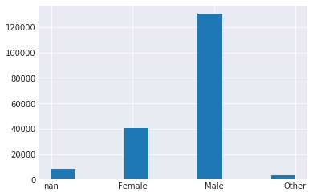

```python
plt.hist(bike.member_gender);
```

I already mentioned that there are NaN values. I decided now that I will keep them since it wouldn't really change anything if I'd imagine these NaN values being distributed into the other three categories. Male would still be highest value, female the second and others third.

```
Thursday     35197
Tuesday      31813
Wednesday    29641
Friday       28981
Monday       26852
Sunday       15523
Saturday     15405
Name: start_day, dtype: int64
```

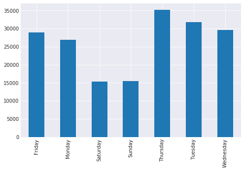

```python
# distribution by day
print(bike.start_day.value_counts())
plt.figure(figsize = [8, 5])
bike['start_day'].value_counts().sort_index().plot.bar(color = base_color)
plt.xticks(rotation = 90);
```

I know this isn't sorted but it's okay for my exploratory analysis. This chart might show that weekends are not the most profitable days. In a matter of fact almost every weekday has twice the amount of rentals (rows) than a weekend day. But this might be misleading, because maybe people rent bikes during weekends for a longer period of time compared to weekdays. This is something for the bivariate part.

```python
# Are there more or less customers than subscribers?
bike.user_type.value_counts()
```

```
Subscriber    163544
Customer       19868
Name: user_type, dtype: int64
```

```python
bike.groupby('user_type').sum()
```

| user_type | duration_sec | start_station_id | start_station_latitude | start_station_longitude | end_station_id | end_station_latitude | end_station_longitude | bike_id | member_birth_year | start_month | end_month | start_time_hour |
| --- | --- | --- | --- | --- | --- | --- | --- | --- | --- | --- | --- | --- |
| Customer | 28460215 | 2663943.0 | 7.506498e+05 | -2.431374e+06 | 2696883.0 | 7.506610e+05 | -2.431365e+06 | 83953231 | 33018540.0 | 39736 | 39740 | 271095 |
| Subscriber | 104711283 | 22727902.0 | 6.177046e+06 | -2.000957e+07 | 22266000.0 | 6.177072e+06 | -2.000951e+07 | 736431473 | 314614353.0 | 327088 | 327100 | 2197341 |

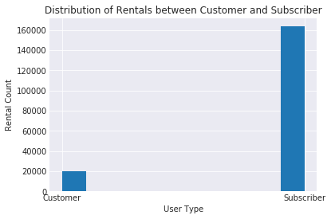

```python
# plotting the difference between Customer and Subscriber rentals
plt.hist(bike.user_type)
plt.xlabel('User Type')
plt.ylabel('Rental Count')
plt.title('Distribution of Rentals between Customer and Subscriber');
```

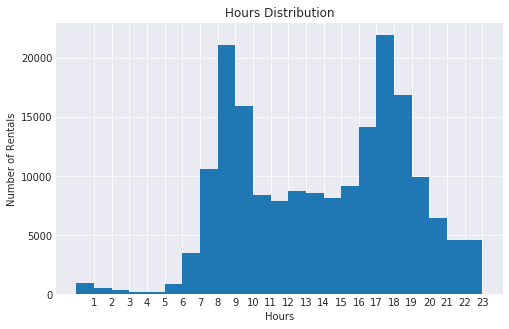

```python
# plotting hours distribution
plt.figure(figsize = [8, 5])
bins = np.arange(0, 24, 1)
plt.hist(data = bike, x = bike.start_time_hour, bins = bins)
ticks = [1, 2, 3, 4, 5, 6, 7, 8, 9, 10, 11, 12, 13, 14, 15, 16, 17, 18, 19, 20, 21, 22, 23]
labels = ['{}'.format(v) for v in ticks]
plt.xticks(ticks, labels)
plt.xlabel('Hours')
plt.ylabel('Number of Rentals')
plt.title('Hours Distribution');
```

### Discuss the distribution(s) of your variable(s) of interest. Were there any unusual points? Did you need to perform any transformations?

I've found out a lot of things like:

- The peak amount of rentals are in rush hour periods - in the morning and evening. This indicates that most people use our bikes to go to work or school. This statement gets stronger when we look at the day and duration_sec distribution. Both weekend days have less rentals compared to weekdays and the mean duration is around 12 minutes. I don't think that you can do sports in just 12 minutes. Looking at these charts makes me believe that most people use it for as I already stated, going to work, school or something similar.
- We have way more male customers than we have female and others.
- There are more subscribers than costumer amount of rentals.

### Of the features you investigated, were there any unusual distributions? Did you perform any operations on the data to tidy, adjust, or change the form of the data? If so, why did you do this?

- I needed to convert the date columns into datetime columns such that I could create new columns for the week days etc.
- User Type column had to be converted into categoricals. I need that to compare them better later in charts.
- I've realised that we have a couple of 'night' users. I came to that observation by comparing the durations in sec. There were some long durations in my observation and I was wondering why. That's why I compared months etc. I want to see if I can find out more about it, but maybe there are just some people who forgot to check out their bikes when they arrived home.

## Bivariate Exploration

We have seen above a big difference between subscribers and customers. How does the proportion look like?

```python
# doing the math - proportions - of user types
c_count = bike.query('user_type == "Customer"')['bike_id'].count()
s_count = bike.query('user_type == "Subscriber"')['bike_id'].count()
c_prop = (c_count / bike['bike_id'].count()) * 100
s_prop = (s_count / bike['bike_id'].count()) * 100
print(c_prop)
print(s_prop)
```

```
10.8324428064
89.1675571936
```

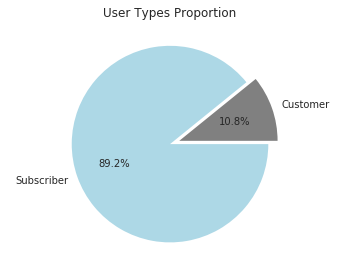

```python
# pie chart to show the proportions visually
labels = ['Customer', 'Subscriber']
sizes = [c_prop, s_prop]
colors = ["grey", "lightblue"]
plt.pie(sizes, explode = (0, 0.1), labels = labels, autopct = '%1.1f%%', colors = colors)
plt.axis('equal')
plt.suptitle('User Types Proportion');
```

The distribution is pretty clear. There are way more rentals done by subscribers than by customers.

As I promised you above, I will show you the comparison of duration amount between nights and days user. Boxplot shows this the best in my opinion.

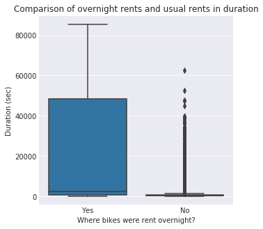

```python
plt.figure(figsize = [5, 5])
sb.set_style('darkgrid')
base_color = sb.color_palette()[0]

sb.boxplot(data = bike, x = 'overnight', y = 'duration_sec', color=base_color)
plt.xlabel('Where bikes were rent overnight?')
plt.ylabel('Duration (sec)')
plt.title('Comparison of overnight rents and usual rents in duration');
```

Wow...This chart is clearer than I expected it to be. It makes sense that when you rent a bike overnight that the duration is usually longer but this chart strengths my hypothesis of people renting bikes during the day **only** for a short period of time.

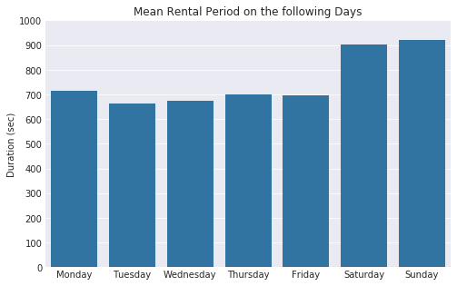

```python
# distribution of mean rental duration per day of the week
plt.figure(figsize = [8, 5])
sb.set_style('darkgrid')

dayorder = ['Monday', 'Tuesday', 'Wednesday', 'Thursday', 'Friday', 'Saturday', 'Sunday']
yticks = np.arange(0, 1100, 100)

g = sb.barplot(data = bike, x = 'start_day', y = 'duration_sec', ci = None, order = dayorder, color = base_color)
g.set_yticks(yticks)
g.set_yticklabels(yticks)
plt.xlabel('')
plt.ylabel('Duration (sec)')
plt.title('Mean Rental Period on the following Days');
```

Now this looks different than the first observation in the univariate chart comparing the rentals to days of the week. The mean duration is higher on weekends than during the week. If I only had the prices for rental duration and the entrance price of starting to rent a bike. This would make such a lovely comparison and I would be able to find out which days are the most profitable. Well, I'll try to find special observations comparing these values and the gender in the multivariate section.

```python
bike.groupby(['start_day']).mean()
```

| start_day | duration_sec | start_station_id | start_station_latitude | start_station_longitude | end_station_id | end_station_latitude | end_station_longitude | bike_id | member_birth_year | start_month | end_month | start_time_hour |
| --- | --- | --- | --- | --- | --- | --- | --- | --- | --- | --- | --- | --- |
| Friday | 695.795073 | 134.297148 | 37.773529 | -122.357521 | 130.508010 | 37.774020 | -122.356788 | 4433.640696 | 1984.509284 | 2.0 | 2.000000 | 12.823022 |
| Monday | 713.159616 | 136.601000 | 37.770312 | -122.351392 | 135.109225 | 37.770431 | -122.351062 | 4380.645650 | 1984.761738 | 2.0 | 2.000000 | 13.395241 |
| Saturday | 902.661993 | 156.513299 | 37.765707 | -122.344056 | 154.688756 | 37.766090 | -122.343911 | 4628.002207 | 1985.862761 | 2.0 | 2.000000 | 13.652126 |
| Sunday | 919.746054 | 158.667613 | 37.767560 | -122.344755 | 157.525447 | 37.767533 | -122.344710 | 4575.100496 | 1986.196738 | 2.0 | 2.000000 | 14.178058 |
| Thursday | 699.040998 | 134.107431 | 37.773063 | -122.355190 | 132.043979 | 37.773182 | -122.354798 | 4490.056681 | 1984.486052 | 2.0 | 2.000455 | 13.620706 |
| Tuesday | 663.305567 | 134.674837 | 37.772271 | -122.353773 | 130.823605 | 37.772497 | -122.353144 | 4400.652249 | 1984.543017 | 2.0 | 2.000000 | 13.229717 |
| Wednesday | 673.671165 | 134.299537 | 37.771270 | -122.353492 | 132.999662 | 37.771374 | -122.353184 | 4517.935697 | 1984.552959 | 2.0 | 2.000000 | 13.712122 |

```python
# checking if night users distort the actual visualizations and investigations of who uses it the most etc.
nighty = bike.query('overnight == "Yes"')
nighty.groupby('start_day').mean()
```

| start_day | duration_sec | start_station_id | start_station_latitude | start_station_longitude | end_station_id | end_station_latitude | end_station_longitude | bike_id | member_birth_year | start_month | end_month | start_time_hour |
| --- | --- | --- | --- | --- | --- | --- | --- | --- | --- | --- | --- | --- |
| Friday | 16816.109091 | 143.981818 | 37.769568 | -122.345273 | 157.236364 | 37.769627 | -122.345187 | 4267.890909 | 1878.836364 | 2.0 | 2.000000 | 21.436364 |
| Monday | 24226.075000 | 108.350000 | 37.793666 | -122.382504 | 127.950000 | 37.790251 | -122.384238 | 3892.600000 | 1833.350000 | 2.0 | 2.000000 | 20.475000 |
| Saturday | 25187.744681 | 111.978723 | 37.781536 | -122.365744 | 149.446809 | 37.782342 | -122.365994 | 4476.085106 | 1860.702128 | 2.0 | 2.000000 | 20.531915 |
| Sunday | 21418.404255 | 162.255319 | 37.782646 | -122.358512 | 184.170213 | 37.779370 | -122.361465 | 3997.063830 | 1567.127660 | 2.0 | 2.000000 | 20.957447 |
| Thursday | 20412.363636 | 162.418182 | 37.760477 | -122.342302 | 152.981818 | 37.757975 | -122.344009 | 4462.181818 | 1588.454545 | 2.0 | 2.290909 | 20.927273 |
| Tuesday | 25079.727273 | 155.727273 | 37.778220 | -122.363252 | 158.212121 | 37.773796 | -122.364985 | 4551.181818 | 1805.515152 | 2.0 | 2.000000 | 20.454545 |
| Wednesday | 26984.930233 | 173.558140 | 37.793063 | -122.371308 | 171.581395 | 37.792658 | -122.371057 | 4930.209302 | 1799.023256 | 2.0 | 2.000000 | 20.116279 |

The duration_sec mean from night users are fairly split up, except Friday, but that's okay. I don't think that I can do something with this information and hence I will drop my investigations.

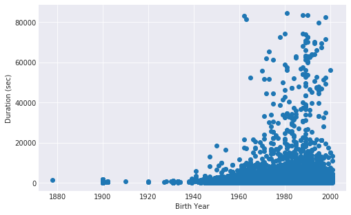

```python
plt.figure(figsize = [8, 5])

plt.scatter(data = bike, x = 'member_birth_year', y = 'duration_sec');
plt.xlabel('Birth Year')
plt.ylabel('Duration (sec)');
```

This chart reveiles some issues. I have to investigate 1880-1920. I really don't believe that 1. there is a guy who is older than 140 and 2. who would ride a bike.

```python
bike[bike['member_birth_year'] <= 1920.0]
```

|  | duration_sec | start_time | end_time | start_station_id | start_station_name | start_station_latitude | start_station_longitude | end_station_id | end_station_name | end_station_latitude | ... | user_type | member_birth_year | member_gender | bike_share_for_all_trip | start_month | start_day | end_month | end_day | start_time_hour | overnight |
| --- | --- | --- | --- | --- | --- | --- | --- | --- | --- | --- | --- | --- | --- | --- | --- | --- | --- | --- | --- | --- | --- |
| 1285 | 148 | 2019-02-28 19:29:17.627 | 2019-02-28 19:31:45.967 | 158.0 | Shattuck Ave at Telegraph Ave | 37.833279 | -122.263490 | 173.0 | Shattuck Ave at 55th St | 37.840364 | ... | Subscriber | 1900.0 | Male | Yes | 2 | Thursday | 2 | Thursday | 19 | No |
| 10827 | 1315 | 2019-02-27 19:21:34.436 | 2019-02-27 19:43:30.008 | 343.0 | Bryant St at 2nd St | 37.783172 | -122.393572 | 375.0 | Grove St at Masonic Ave | 37.774836 | ... | Subscriber | 1900.0 | Male | No | 2 | Wednesday | 2 | Wednesday | 19 | No |
| 16087 | 1131 | 2019-02-27 08:37:36.864 | 2019-02-27 08:56:28.022 | 375.0 | Grove St at Masonic Ave | 37.774836 | -122.446546 | 36.0 | Folsom St at 3rd St | 37.783830 | ... | Subscriber | 1900.0 | Male | No | 2 | Wednesday | 2 | Wednesday | 8 | No |
| 17981 | 366 | 2019-02-26 19:53:38.528 | 2019-02-26 19:59:44.968 | 50.0 | 2nd St at Townsend St | 37.780526 | -122.390288 | 21.0 | Montgomery St BART Station (Market St at 2nd St) | 37.789625 | ... | Subscriber | 1920.0 | Male | No | 2 | Tuesday | 2 | Tuesday | 19 | No |
| 18885 | 432 | 2019-02-26 17:48:59.016 | 2019-02-26 17:56:11.370 | 21.0 | Montgomery St BART Station (Market St at 2nd St) | 37.789625 | -122.400811 | 50.0 | 2nd St at Townsend St | 37.780526 | ... | Subscriber | 1920.0 | Male | No | 2 | Tuesday | 2 | Tuesday | 17 | No |
| 19375 | 641 | 2019-02-26 17:03:19.855 | 2019-02-26 17:14:01.619 | 9.0 | Broadway at Battery St | 37.798572 | -122.400869 | 30.0 | San Francisco Caltrain (Townsend St at 4th St) | 37.776598 | ... | Customer | 1900.0 | Male | No | 2 | Tuesday | 2 | Tuesday | 17 | No |
| 21424 | 1424 | 2019-02-26 08:58:02.904 | 2019-02-26 09:21:47.749 | 375.0 | Grove St at Masonic Ave | 37.774836 | -122.446546 | 343.0 | Bryant St at 2nd St | 37.783172 | ... | Subscriber | 1900.0 | Male | No | 2 | Tuesday | 2 | Tuesday | 8 | No |
| 21506 | 701 | 2019-02-26 09:06:11.239 | 2019-02-26 09:17:52.442 | 67.0 | San Francisco Caltrain Station 2 (Townsend St... | 37.776639 | -122.395526 | 9.0 | Broadway at Battery St | 37.798572 | ... | Customer | 1900.0 | Male | No | 2 | Tuesday | 2 | Tuesday | 9 | No |
| 24042 | 194 | 2019-02-25 18:58:10.644 | 2019-02-25 19:01:25.308 | 158.0 | Shattuck Ave at Telegraph Ave | 37.833279 | -122.263490 | 173.0 | Shattuck Ave at 55th St | 37.840364 | ... | Subscriber | 1900.0 | Male | Yes | 2 | Monday | 2 | Monday | 18 | No |
| 26133 | 410 | 2019-02-25 13:38:12.067 | 2019-02-25 13:45:02.207 | 173.0 | Shattuck Ave at 55th St | 37.840364 | -122.264488 | 176.0 | MacArthur BART Station | 37.828410 | ... | Subscriber | 1900.0 | Male | Yes | 2 | Monday | 2 | Monday | 13 | No |
| 27370 | 1474 | 2019-02-25 09:28:42.161 | 2019-02-25 09:53:17.068 | 15.0 | San Francisco Ferry Building (Harry Bridges Pl... | 37.795392 | -122.394203 | 386.0 | 24th St at Bartlett St | 37.752105 | ... | Customer | 1878.0 | Female | No | 2 | Monday | 2 | Monday | 9 | No |
| 27675 | 1087 | 2019-02-25 09:10:39.549 | 2019-02-25 09:28:46.676 | 375.0 | Grove St at Masonic Ave | 37.774836 | -122.446546 | 36.0 | Folsom St at 3rd St | 37.783830 | ... | Subscriber | 1900.0 | Male | No | 2 | Monday | 2 | Monday | 9 | No |
| 29716 | 403 | 2019-02-25 06:46:30.448 | 2019-02-25 06:53:13.914 | 284.0 | Yerba Buena Center for the Arts (Howard St at ... | 37.784872 | -122.400876 | 30.0 | San Francisco Caltrain (Townsend St at 4th St) | 37.776598 | ... | Subscriber | 1901.0 | Male | No | 2 | Monday | 2 | Monday | 6 | No |
| 32285 | 299 | 2019-02-24 14:48:50.554 | 2019-02-24 14:53:50.330 | 179.0 | Telegraph Ave at 27th St | 37.816073 | -122.267886 | 195.0 | Bay Pl at Vernon St | 37.812314 | ... | Subscriber | 1900.0 | Female | No | 2 | Sunday | 2 | Sunday | 14 | No |
| 32725 | 85 | 2019-02-24 13:49:52.142 | 2019-02-24 13:51:17.904 | 174.0 | Shattuck Ave at 51st St | 37.836801 | -122.264004 | 173.0 | Shattuck Ave at 55th St | 37.840364 | ... | Subscriber | 1900.0 | Male | Yes | 2 | Sunday | 2 | Sunday | 13 | No |
| 32809 | 395 | 2019-02-24 13:32:43.034 | 2019-02-24 13:39:18.303 | 195.0 | Bay Pl at Vernon St | 37.812314 | -122.260779 | 179.0 | Telegraph Ave at 27th St | 37.816073 | ... | Subscriber | 1900.0 | Female | No | 2 | Sunday | 2 | Sunday | 13 | No |
| 32942 | 169 | 2019-02-24 13:17:05.233 | 2019-02-24 13:19:54.375 | 173.0 | Shattuck Ave at 55th St | 37.840364 | -122.264488 | 174.0 | Shattuck Ave at 51st St | 37.836801 | ... | Subscriber | 1900.0 | Male | Yes | 2 | Sunday | 2 | Sunday | 13 | No |
| 34747 | 180 | 2019-02-23 21:46:26.558 | 2019-02-23 21:49:26.839 | 174.0 | Shattuck Ave at 51st St | 37.836801 | -122.264004 | 204.0 | 55th St at Telegraph Ave | 37.840186 | ... | Subscriber | 1900.0 | Male | Yes | 2 | Saturday | 2 | Saturday | 21 | No |
| 38932 | 389 | 2019-02-23 10:49:33.547 | 2019-02-23 10:56:03.428 | 173.0 | Shattuck Ave at 55th St | 37.840364 | -122.264488 | 150.0 | Adeline St at 40th St | 37.831277 | ... | Subscriber | 1900.0 | Male | Yes | 2 | Saturday | 2 | Saturday | 10 | No |
| 41194 | 313 | 2019-02-22 18:55:09.207 | 2019-02-22 19:00:22.969 | 340.0 | Harmon St at Adeline St | 37.849735 | -122.270582 | 173.0 | Shattuck Ave at 55th St | 37.840364 | ... | Subscriber | 1900.0 | Male | Yes | 2 | Friday | 2 | Friday | 18 | No |
| 41246 | 539 | 2019-02-22 18:46:15.403 | 2019-02-22 18:55:15.053 | 30.0 | San Francisco Caltrain (Townsend St at 4th St) | 37.776598 | -122.395282 | 25.0 | Howard St at 2nd St | 37.787522 | ... | Subscriber | 1901.0 | Male | No | 2 | Friday | 2 | Friday | 18 | No |
| 41319 | 379 | 2019-02-22 18:43:07.018 | 2019-02-22 18:49:26.251 | 173.0 | Shattuck Ave at 55th St | 37.840364 | -122.264488 | 340.0 | Harmon St at Adeline St | 37.849735 | ... | Subscriber | 1900.0 | Male | Yes | 2 | Friday | 2 | Friday | 18 | No |
| 43259 | 676 | 2019-02-22 16:44:42.778 | 2019-02-22 16:55:59.387 | 21.0 | Montgomery St BART Station (Market St at 2nd St) | 37.789625 | -122.400811 | 67.0 | San Francisco Caltrain Station 2 (Townsend St... | 37.776639 | ... | Subscriber | 1920.0 | Male | No | 2 | Friday | 2 | Friday | 16 | No |
| 43880 | 379 | 2019-02-22 15:58:02.725 | 2019-02-22 16:04:22.189 | 39.0 | Scott St at Golden Gate Ave | 37.778999 | -122.436861 | 74.0 | Laguna St at Hayes St | 37.776435 | ... | Customer | 1900.0 | Male | No | 2 | Friday | 2 | Friday | 15 | No |
| 45846 | 1336 | 2019-02-22 10:53:45.889 | 2019-02-22 11:16:02.793 | 74.0 | Laguna St at Hayes St | 37.776435 | -122.426244 | 377.0 | Fell St at Stanyan St | 37.771917 | ... | Customer | 1900.0 | Male | No | 2 | Friday | 2 | Friday | 10 | No |
| 48804 | 387 | 2019-02-22 07:01:50.431 | 2019-02-22 07:08:18.080 | 284.0 | Yerba Buena Center for the Arts (Howard St at ... | 37.784872 | -122.400876 | 30.0 | San Francisco Caltrain (Townsend St at 4th St) | 37.776598 | ... | Subscriber | 1901.0 | Male | No | 2 | Friday | 2 | Friday | 7 | No |
| 58222 | 1055 | 2019-02-21 07:05:11.790 | 2019-02-21 07:22:47.591 | 375.0 | Grove St at Masonic Ave | 37.774836 | -122.446546 | 36.0 | Folsom St at 3rd St | 37.783830 | ... | Subscriber | 1900.0 | Male | No | 2 | Thursday | 2 | Thursday | 7 | No |
| 60960 | 339 | 2019-02-20 18:08:14.886 | 2019-02-20 18:13:54.858 | 177.0 | MacArthur Blvd at Telegraph Ave | 37.826286 | -122.265100 | 173.0 | Shattuck Ave at 55th St | 37.840364 | ... | Subscriber | 1900.0 | Male | Yes | 2 | Wednesday | 2 | Wednesday | 18 | No |
| 61611 | 87 | 2019-02-20 17:41:14.387 | 2019-02-20 17:42:41.909 | 176.0 | MacArthur BART Station | 37.828410 | -122.266315 | 177.0 | MacArthur Blvd at Telegraph Ave | 37.826286 | ... | Subscriber | 1900.0 | Male | Yes | 2 | Wednesday | 2 | Wednesday | 17 | No |
| 62598 | 1420 | 2019-02-20 16:27:23.109 | 2019-02-20 16:51:03.781 | 343.0 | Bryant St at 2nd St | 37.783172 | -122.393572 | 375.0 | Grove St at Masonic Ave | 37.774836 | ... | Subscriber | 1900.0 | Male | No | 2 | Wednesday | 2 | Wednesday | 16 | No |
| ... | ... | ... | ... | ... | ... | ... | ... | ... | ... | ... | ... | ... | ... | ... | ... | ... | ... | ... | ... | ... | ... |
| 107359 | 1893 | 2019-02-13 16:00:17.388 | 2019-02-13 16:31:51.002 | 343.0 | Bryant St at 2nd St | 37.783172 | -122.393572 | 375.0 | Grove St at Masonic Ave | 37.774836 | ... | Subscriber | 1900.0 | Male | No | 2 | Wednesday | 2 | Wednesday | 16 | No |
| 107619 | 217 | 2019-02-13 15:37:31.735 | 2019-02-13 15:41:09.510 | 158.0 | Shattuck Ave at Telegraph Ave | 37.833279 | -122.263490 | 173.0 | Shattuck Ave at 55th St | 37.840364 | ... | Subscriber | 1900.0 | Male | Yes | 2 | Wednesday | 2 | Wednesday | 15 | No |
| 108314 | 1303 | 2019-02-13 08:34:51.645 | 2019-02-13 08:56:34.749 | 375.0 | Grove St at Masonic Ave | 37.774836 | -122.446546 | 36.0 | Folsom St at 3rd St | 37.783830 | ... | Subscriber | 1900.0 | Male | No | 2 | Wednesday | 2 | Wednesday | 8 | No |
| 109010 | 431 | 2019-02-12 20:30:25.977 | 2019-02-12 20:37:37.668 | 215.0 | 34th St at Telegraph Ave | 37.822547 | -122.266318 | 173.0 | Shattuck Ave at 55th St | 37.840364 | ... | Subscriber | 1900.0 | Male | Yes | 2 | Tuesday | 2 | Tuesday | 20 | No |
| 110468 | 257 | 2019-02-12 18:00:27.822 | 2019-02-12 18:04:45.246 | 158.0 | Shattuck Ave at Telegraph Ave | 37.833279 | -122.263490 | 215.0 | 34th St at Telegraph Ave | 37.822547 | ... | Subscriber | 1900.0 | Male | Yes | 2 | Tuesday | 2 | Tuesday | 18 | No |
| 110734 | 794 | 2019-02-12 17:38:26.377 | 2019-02-12 17:51:40.784 | 173.0 | Shattuck Ave at 55th St | 37.840364 | -122.264488 | 158.0 | Shattuck Ave at Telegraph Ave | 37.833279 | ... | Subscriber | 1900.0 | Male | Yes | 2 | Tuesday | 2 | Tuesday | 17 | No |
| 114762 | 543 | 2019-02-12 09:12:25.266 | 2019-02-12 09:21:28.581 | 30.0 | San Francisco Caltrain (Townsend St at 4th St) | 37.776598 | -122.395282 | 26.0 | 1st St at Folsom St | 37.787290 | ... | Subscriber | 1902.0 | Female | No | 2 | Tuesday | 2 | Tuesday | 9 | No |
| 115637 | 1034 | 2019-02-12 08:23:30.357 | 2019-02-12 08:40:44.747 | 375.0 | Grove St at Masonic Ave | 37.774836 | -122.446546 | 36.0 | Folsom St at 3rd St | 37.783830 | ... | Subscriber | 1900.0 | Male | No | 2 | Tuesday | 2 | Tuesday | 8 | No |
| 119010 | 267 | 2019-02-11 18:19:18.848 | 2019-02-11 18:23:46.758 | 158.0 | Shattuck Ave at Telegraph Ave | 37.833279 | -122.263490 | 173.0 | Shattuck Ave at 55th St | 37.840364 | ... | Subscriber | 1900.0 | Male | Yes | 2 | Monday | 2 | Monday | 18 | No |
| 122194 | 1657 | 2019-02-11 12:19:26.064 | 2019-02-11 12:47:03.298 | 377.0 | Fell St at Stanyan St | 37.771917 | -122.453704 | 36.0 | Folsom St at 3rd St | 37.783830 | ... | Subscriber | 1900.0 | Male | No | 2 | Monday | 2 | Monday | 12 | No |
| 123240 | 562 | 2019-02-11 09:36:13.876 | 2019-02-11 09:45:36.806 | 30.0 | San Francisco Caltrain (Townsend St at 4th St) | 37.776598 | -122.395282 | 26.0 | 1st St at Folsom St | 37.787290 | ... | Subscriber | 1902.0 | Female | No | 2 | Monday | 2 | Monday | 9 | No |
| 128986 | 520 | 2019-02-10 11:48:51.152 | 2019-02-10 11:57:31.632 | 173.0 | Shattuck Ave at 55th St | 37.840364 | -122.264488 | 150.0 | Adeline St at 40th St | 37.831277 | ... | Subscriber | 1900.0 | Male | Yes | 2 | Sunday | 2 | Sunday | 11 | No |
| 137804 | 372 | 2019-02-08 08:22:24.741 | 2019-02-08 08:28:37.126 | 30.0 | San Francisco Caltrain (Townsend St at 4th St) | 37.776598 | -122.395282 | 26.0 | 1st St at Folsom St | 37.787290 | ... | Subscriber | 1902.0 | Female | No | 2 | Friday | 2 | Friday | 8 | No |
| 138297 | 491 | 2019-02-08 07:44:39.461 | 2019-02-08 07:52:51.140 | 284.0 | Yerba Buena Center for the Arts (Howard St at ... | 37.784872 | -122.400876 | 30.0 | San Francisco Caltrain (Townsend St at 4th St) | 37.776598 | ... | Subscriber | 1901.0 | Male | No | 2 | Friday | 2 | Friday | 7 | No |
| 140748 | 481 | 2019-02-07 18:41:11.650 | 2019-02-07 18:49:13.254 | 25.0 | Howard St at 2nd St | 37.787522 | -122.397405 | 30.0 | San Francisco Caltrain (Townsend St at 4th St) | 37.776598 | ... | Subscriber | 1902.0 | Female | No | 2 | Thursday | 2 | Thursday | 18 | No |
| 145510 | 508 | 2019-02-07 09:34:11.542 | 2019-02-07 09:42:40.400 | 30.0 | San Francisco Caltrain (Townsend St at 4th St) | 37.776598 | -122.395282 | 26.0 | 1st St at Folsom St | 37.787290 | ... | Subscriber | 1902.0 | Female | No | 2 | Thursday | 2 | Thursday | 9 | No |
| 147519 | 460 | 2019-02-07 07:44:28.217 | 2019-02-07 07:52:08.390 | 284.0 | Yerba Buena Center for the Arts (Howard St at ... | 37.784872 | -122.400876 | 30.0 | San Francisco Caltrain (Townsend St at 4th St) | 37.776598 | ... | Subscriber | 1901.0 | Male | No | 2 | Thursday | 2 | Thursday | 7 | No |
| 150108 | 727 | 2019-02-06 18:24:40.310 | 2019-02-06 18:36:48.183 | 81.0 | Berry St at 4th St | 37.775880 | -122.393170 | 284.0 | Yerba Buena Center for the Arts (Howard St at ... | 37.784872 | ... | Subscriber | 1910.0 | Other | No | 2 | Wednesday | 2 | Wednesday | 18 | No |
| 151936 | 622 | 2019-02-06 16:42:11.928 | 2019-02-06 16:52:34.230 | 25.0 | Howard St at 2nd St | 37.787522 | -122.397405 | 30.0 | San Francisco Caltrain (Townsend St at 4th St) | 37.776598 | ... | Subscriber | 1902.0 | Female | No | 2 | Wednesday | 2 | Wednesday | 16 | No |
| 161505 | 355 | 2019-02-05 14:43:59.227 | 2019-02-05 14:49:54.267 | 25.0 | Howard St at 2nd St | 37.787522 | -122.397405 | 30.0 | San Francisco Caltrain (Townsend St at 4th St) | 37.776598 | ... | Subscriber | 1902.0 | Female | No | 2 | Tuesday | 2 | Tuesday | 14 | No |
| 162051 | 176 | 2019-02-05 13:00:00.604 | 2019-02-05 13:02:57.549 | 173.0 | Shattuck Ave at 55th St | 37.840364 | -122.264488 | 174.0 | Shattuck Ave at 51st St | 37.836801 | ... | Subscriber | 1900.0 | Male | Yes | 2 | Tuesday | 2 | Tuesday | 13 | No |
| 163112 | 1640 | 2019-02-05 09:18:18.397 | 2019-02-05 09:45:39.016 | 377.0 | Fell St at Stanyan St | 37.771917 | -122.453704 | 36.0 | Folsom St at 3rd St | 37.783830 | ... | Subscriber | 1900.0 | Male | No | 2 | Tuesday | 2 | Tuesday | 9 | No |
| 167178 | 526 | 2019-02-04 17:36:54.155 | 2019-02-04 17:45:41.140 | 25.0 | Howard St at 2nd St | 37.787522 | -122.397405 | 30.0 | San Francisco Caltrain (Townsend St at 4th St) | 37.776598 | ... | Subscriber | 1902.0 | Female | No | 2 | Monday | 2 | Monday | 17 | No |
| 171086 | 1086 | 2019-02-04 06:30:33.383 | 2019-02-04 06:48:39.869 | 375.0 | Grove St at Masonic Ave | 37.774836 | -122.446546 | 36.0 | Folsom St at 3rd St | 37.783830 | ... | Subscriber | 1900.0 | Male | No | 2 | Monday | 2 | Monday | 6 | No |
| 171757 | 94 | 2019-02-03 19:12:06.607 | 2019-02-03 19:13:40.671 | 173.0 | Shattuck Ave at 55th St | 37.840364 | -122.264488 | 174.0 | Shattuck Ave at 51st St | 37.836801 | ... | Subscriber | 1900.0 | Male | Yes | 2 | Sunday | 2 | Sunday | 19 | No |
| 171996 | 1368 | 2019-02-03 17:33:54.607 | 2019-02-03 17:56:42.949 | 37.0 | 2nd St at Folsom St | 37.785000 | -122.395936 | 375.0 | Grove St at Masonic Ave | 37.774836 | ... | Subscriber | 1900.0 | Male | No | 2 | Sunday | 2 | Sunday | 17 | No |
| 173711 | 993 | 2019-02-03 09:45:30.464 | 2019-02-03 10:02:04.169 | 375.0 | Grove St at Masonic Ave | 37.774836 | -122.446546 | 36.0 | Folsom St at 3rd St | 37.783830 | ... | Subscriber | 1900.0 | Male | No | 2 | Sunday | 2 | Sunday | 9 | No |
| 177708 | 1527 | 2019-02-01 19:09:28.387 | 2019-02-01 19:34:55.963 | 343.0 | Bryant St at 2nd St | 37.783172 | -122.393572 | 375.0 | Grove St at Masonic Ave | 37.774836 | ... | Subscriber | 1900.0 | Male | No | 2 | Friday | 2 | Friday | 19 | No |
| 177885 | 517 | 2019-02-01 18:38:40.471 | 2019-02-01 18:47:18.392 | 25.0 | Howard St at 2nd St | 37.787522 | -122.397405 | 30.0 | San Francisco Caltrain (Townsend St at 4th St) | 37.776598 | ... | Subscriber | 1902.0 | Female | No | 2 | Friday | 2 | Friday | 18 | No |
| 182830 | 428 | 2019-02-01 07:45:05.934 | 2019-02-01 07:52:14.922 | 284.0 | Yerba Buena Center for the Arts (Howard St at ... | 37.784872 | -122.400876 | 67.0 | San Francisco Caltrain Station 2 (Townsend St... | 37.776639 | ... | Subscriber | 1901.0 | Male | No | 2 | Friday | 2 | Friday | 7 | No |

75 rows × 22 columns

```python
bike[bike['member_birth_year'] > 2000.0]
```

|  | duration_sec | start_time | end_time | start_station_id | start_station_name | start_station_latitude | start_station_longitude | end_station_id | end_station_name | end_station_latitude | ... | user_type | member_birth_year | member_gender | bike_share_for_all_trip | start_month | start_day | end_month | end_day | start_time_hour | overnight |
| --- | --- | --- | --- | --- | --- | --- | --- | --- | --- | --- | --- | --- | --- | --- | --- | --- | --- | --- | --- | --- | --- |
| 25860 | 669 | 2019-02-25 15:48:17.944 | 2019-02-25 15:59:27.822 | 112.0 | Harrison St at 17th St | 37.763847 | -122.413004 | 43.0 | San Francisco Public Library (Grove St at Hyde... | 37.778768 | ... | Customer | 2001.0 | Male | No | 2 | Monday | 2 | Monday | 15 | No |
| 39355 | 585 | 2019-02-23 09:24:57.766 | 2019-02-23 09:34:43.649 | 249.0 | Russell St at College Ave | 37.858473 | -122.253253 | 171.0 | Rockridge BART Station | 37.844279 | ... | Subscriber | 2001.0 | Female | No | 2 | Saturday | 2 | Saturday | 9 | No |
| 45335 | 4437 | 2019-02-22 11:23:21.817 | 2019-02-22 12:37:19.092 | 3.0 | Powell St BART Station (Market St at 4th St) | 37.786375 | -122.404904 | 365.0 | Turk St at Fillmore St | 37.780450 | ... | Customer | 2001.0 | Male | No | 2 | Friday | 2 | Friday | 11 | No |
| 45338 | 4414 | 2019-02-22 11:23:29.815 | 2019-02-22 12:37:04.211 | 3.0 | Powell St BART Station (Market St at 4th St) | 37.786375 | -122.404904 | 365.0 | Turk St at Fillmore St | 37.780450 | ... | Customer | 2001.0 | Male | No | 2 | Friday | 2 | Friday | 11 | No |
| 62719 | 1895 | 2019-02-20 16:08:45.440 | 2019-02-20 16:40:21.050 | 200.0 | 2nd Ave at E 18th St | 37.800214 | -122.253810 | 338.0 | 13th St at Franklin St | 37.803189 | ... | Customer | 2001.0 | Male | No | 2 | Wednesday | 2 | Wednesday | 16 | No |
| 62720 | 1895 | 2019-02-20 16:08:44.560 | 2019-02-20 16:40:20.001 | 200.0 | 2nd Ave at E 18th St | 37.800214 | -122.253810 | 338.0 | 13th St at Franklin St | 37.803189 | ... | Customer | 2001.0 | Male | No | 2 | Wednesday | 2 | Wednesday | 16 | No |
| 63129 | 1777 | 2019-02-20 15:29:22.403 | 2019-02-20 15:58:59.980 | 285.0 | Webster St at O'Farrell St | 37.783521 | -122.431158 | 377.0 | Fell St at Stanyan St | 37.771917 | ... | Customer | 2001.0 | Male | No | 2 | Wednesday | 2 | Wednesday | 15 | No |
| 63137 | 1734 | 2019-02-20 15:29:31.069 | 2019-02-20 15:58:25.510 | 285.0 | Webster St at O'Farrell St | 37.783521 | -122.431158 | 377.0 | Fell St at Stanyan St | 37.771917 | ... | Customer | 2001.0 | Male | No | 2 | Wednesday | 2 | Wednesday | 15 | No |
| 63620 | 1554 | 2019-02-20 14:06:52.179 | 2019-02-20 14:32:46.706 | 3.0 | Powell St BART Station (Market St at 4th St) | 37.786375 | -122.404904 | 285.0 | Webster St at O'Farrell St | 37.783521 | ... | Customer | 2001.0 | Male | No | 2 | Wednesday | 2 | Wednesday | 14 | No |
| 63623 | 1558 | 2019-02-20 14:06:33.178 | 2019-02-20 14:32:31.688 | 3.0 | Powell St BART Station (Market St at 4th St) | 37.786375 | -122.404904 | 285.0 | Webster St at O'Farrell St | 37.783521 | ... | Customer | 2001.0 | Male | No | 2 | Wednesday | 2 | Wednesday | 14 | No |
| 65310 | 832 | 2019-02-20 09:41:26.073 | 2019-02-20 09:55:18.664 | 249.0 | Russell St at College Ave | 37.858473 | -122.253253 | 246.0 | Berkeley Civic Center | 37.869060 | ... | Subscriber | 2001.0 | Female | No | 2 | Wednesday | 2 | Wednesday | 9 | No |
| 74295 | 1746 | 2019-02-19 10:33:24.602 | 2019-02-19 11:02:30.632 | 250.0 | North Berkeley BART Station | 37.873558 | -122.283093 | 256.0 | Hearst Ave at Euclid Ave | 37.875112 | ... | Customer | 2001.0 | Male | No | 2 | Tuesday | 2 | Tuesday | 10 | No |
| 79886 | 1787 | 2019-02-18 16:21:15.875 | 2019-02-18 16:51:03.741 | 6.0 | The Embarcadero at Sansome St | 37.804770 | -122.403234 | 81.0 | Berry St at 4th St | 37.775880 | ... | Customer | 2001.0 | Female | No | 2 | Monday | 2 | Monday | 16 | No |
| 79887 | 1801 | 2019-02-18 16:21:00.638 | 2019-02-18 16:51:02.430 | 6.0 | The Embarcadero at Sansome St | 37.804770 | -122.403234 | 81.0 | Berry St at 4th St | 37.775880 | ... | Customer | 2001.0 | Female | No | 2 | Monday | 2 | Monday | 16 | No |
| 84682 | 1659 | 2019-02-17 16:41:26.874 | 2019-02-17 17:09:06.393 | 6.0 | The Embarcadero at Sansome St | 37.804770 | -122.403234 | 20.0 | Mechanics Monument Plaza (Market St at Bush St) | 37.791300 | ... | Customer | 2001.0 | Female | No | 2 | Sunday | 2 | Sunday | 16 | No |
| 84685 | 1481 | 2019-02-17 16:44:17.965 | 2019-02-17 17:08:59.276 | 6.0 | The Embarcadero at Sansome St | 37.804770 | -122.403234 | 20.0 | Mechanics Monument Plaza (Market St at Bush St) | 37.791300 | ... | Customer | 2001.0 | Female | No | 2 | Sunday | 2 | Sunday | 16 | No |
| 84849 | 73 | 2019-02-17 16:41:38.264 | 2019-02-17 16:42:51.818 | 6.0 | The Embarcadero at Sansome St | 37.804770 | -122.403234 | 6.0 | The Embarcadero at Sansome St | 37.804770 | ... | Customer | 2001.0 | Female | No | 2 | Sunday | 2 | Sunday | 16 | No |
| 86630 | 1187 | 2019-02-17 12:07:44.740 | 2019-02-17 12:27:32.024 | 15.0 | San Francisco Ferry Building (Harry Bridges Pl... | 37.795392 | -122.394203 | 6.0 | The Embarcadero at Sansome St | 37.804770 | ... | Customer | 2001.0 | Female | No | 2 | Sunday | 2 | Sunday | 12 | No |
| 86631 | 1148 | 2019-02-17 12:08:15.037 | 2019-02-17 12:27:23.996 | 15.0 | San Francisco Ferry Building (Harry Bridges Pl... | 37.795392 | -122.394203 | 6.0 | The Embarcadero at Sansome St | 37.804770 | ... | Customer | 2001.0 | Female | No | 2 | Sunday | 2 | Sunday | 12 | No |
| 90142 | 785 | 2019-02-16 13:30:01.304 | 2019-02-16 13:43:06.672 | 249.0 | Russell St at College Ave | 37.858473 | -122.253253 | 171.0 | Rockridge BART Station | 37.844279 | ... | Subscriber | 2001.0 | Female | No | 2 | Saturday | 2 | Saturday | 13 | No |
| 111857 | 828 | 2019-02-12 16:29:35.516 | 2019-02-12 16:43:23.803 | 87.0 | Folsom St at 13th St | 37.769757 | -122.415674 | 86.0 | Market St at Dolores St | 37.769305 | ... | Customer | 2001.0 | Male | No | 2 | Tuesday | 2 | Tuesday | 16 | No |
| 123173 | 722 | 2019-02-11 09:39:32.834 | 2019-02-11 09:51:34.906 | 249.0 | Russell St at College Ave | 37.858473 | -122.253253 | 246.0 | Berkeley Civic Center | 37.869060 | ... | Subscriber | 2001.0 | Female | No | 2 | Monday | 2 | Monday | 9 | No |
| 127543 | 13412 | 2019-02-10 11:59:39.672 | 2019-02-10 15:43:12.305 | 259.0 | Addison St at Fourth St | 37.866249 | -122.299371 | 259.0 | Addison St at Fourth St | 37.866249 | ... | Subscriber | 2001.0 | Female | No | 2 | Sunday | 2 | Sunday | 11 | No |
| 157448 | 3181 | 2019-02-05 21:12:10.333 | 2019-02-05 22:05:11.985 | 383.0 | Golden Gate Ave at Franklin St | 37.780787 | -122.421934 | 383.0 | Golden Gate Ave at Franklin St | 37.780787 | ... | Customer | 2001.0 | Female | No | 2 | Tuesday | 2 | Tuesday | 21 | No |
| 157450 | 3161 | 2019-02-05 21:12:23.285 | 2019-02-05 22:05:04.893 | 383.0 | Golden Gate Ave at Franklin St | 37.780787 | -122.421934 | 383.0 | Golden Gate Ave at Franklin St | 37.780787 | ... | Customer | 2001.0 | Female | No | 2 | Tuesday | 2 | Tuesday | 21 | No |
| 157451 | 3169 | 2019-02-05 21:12:12.268 | 2019-02-05 22:05:01.902 | 383.0 | Golden Gate Ave at Franklin St | 37.780787 | -122.421934 | 383.0 | Golden Gate Ave at Franklin St | 37.780787 | ... | Customer | 2001.0 | Female | No | 2 | Tuesday | 2 | Tuesday | 21 | No |
| 157452 | 3079 | 2019-02-05 21:13:20.951 | 2019-02-05 22:04:40.482 | 383.0 | Golden Gate Ave at Franklin St | 37.780787 | -122.421934 | 383.0 | Golden Gate Ave at Franklin St | 37.780787 | ... | Customer | 2001.0 | Female | No | 2 | Tuesday | 2 | Tuesday | 21 | No |
| 162755 | 900 | 2019-02-05 10:13:08.238 | 2019-02-05 10:28:08.757 | 249.0 | Russell St at College Ave | 37.858473 | -122.253253 | 246.0 | Berkeley Civic Center | 37.869060 | ... | Subscriber | 2001.0 | Female | No | 2 | Tuesday | 2 | Tuesday | 10 | No |
| 176045 | 981 | 2019-02-02 12:33:26.620 | 2019-02-02 12:49:48.314 | 6.0 | The Embarcadero at Sansome St | 37.804770 | -122.403234 | 19.0 | Post St at Kearny St | 37.788975 | ... | Customer | 2001.0 | Male | No | 2 | Saturday | 2 | Saturday | 12 | No |
| 176639 | 11063 | 2019-02-02 07:55:46.804 | 2019-02-02 11:00:10.190 | 370.0 | Jones St at Post St | 37.787327 | -122.413278 | 6.0 | The Embarcadero at Sansome St | 37.804770 | ... | Customer | 2001.0 | Male | No | 2 | Saturday | 2 | Saturday | 7 | No |
| 179315 | 1121 | 2019-02-01 14:12:12.099 | 2019-02-01 14:30:53.901 | 6.0 | The Embarcadero at Sansome St | 37.804770 | -122.403234 | 370.0 | Jones St at Post St | 37.787327 | ... | Customer | 2001.0 | Male | No | 2 | Friday | 2 | Friday | 14 | No |
| 179375 | 6508 | 2019-02-01 12:21:19.721 | 2019-02-01 14:09:48.338 | 370.0 | Jones St at Post St | 37.787327 | -122.413278 | 6.0 | The Embarcadero at Sansome St | 37.804770 | ... | Customer | 2001.0 | Male | No | 2 | Friday | 2 | Friday | 12 | No |
| 180263 | 1355 | 2019-02-01 11:20:08.606 | 2019-02-01 11:42:43.937 | 36.0 | Folsom St at 3rd St | 37.783830 | -122.398870 | 370.0 | Jones St at Post St | 37.787327 | ... | Customer | 2001.0 | Male | No | 2 | Friday | 2 | Friday | 11 | No |
| 181314 | 630 | 2019-02-01 09:14:35.998 | 2019-02-01 09:25:06.012 | 249.0 | Russell St at College Ave | 37.858473 | -122.253253 | 246.0 | Berkeley Civic Center | 37.869060 | ... | Subscriber | 2001.0 | Female | No | 2 | Friday | 2 | Friday | 9 | No |

34 rows × 22 columns

Being 18 years old riding a bike makes sense but being 100 years old and riding a bike looks like a curiousity. Not that I think this wasn't possible but let's be honest, how often do you see an elderly riding a rented bike? I've nevers seen anyone. I will delete every row with birth year 1925.

```python
bike.drop(bike[bike['member_birth_year'] <= 1925.0].index, inplace = True)
```

```python
bike[bike['member_birth_year'] <= 1925.0]
```

|  | duration_sec | start_time | end_time | start_station_id | start_station_name | start_station_latitude | start_station_longitude | end_station_id | end_station_name | end_station_latitude | ... | user_type | member_birth_year | member_gender | bike_share_for_all_trip | start_month | start_day | end_month | end_day | start_time_hour | overnight |
| --- | --- | --- | --- | --- | --- | --- | --- | --- | --- | --- | --- | --- | --- | --- | --- | --- | --- | --- | --- | --- | --- |

0 rows × 22 columns

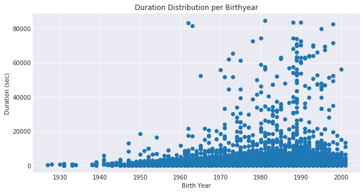

```python
plt.figure(figsize = [10, 5])

plt.scatter(data = bike, x = 'member_birth_year', y = 'duration_sec');
plt.xlabel('Birth Year')
plt.ylabel('Duration (sec)')
plt.title('Duration Distribution per Birthyear');
```

### Talk about some of the relationships you observed in this part of the investigation. How did the feature(s) of interest vary with other features in the dataset?

- I visualized and made the huge difference between subscribers and customers more recognizable with a pie chart. It's very healthy for a company to have more subscribers than irregular customers. This shows that the company has good customer loyalty and an existing customer base.
- In the first part we've seen that weekdays have more rentals than weekdays. Now I showed you that the mean duration is higher in the weekends. This strenghtens my intuition even more about people using bikes for going to work.

### Did you observe any interesting relationships between the other features (not the main feature(s) of interest)?

- I did find an interesting relationship...a relationship between years and durations. It's not something I planned on investigation. It's more something I stumbled up upon. There is no possibility that there are a bunch of people riding our bikes with an age of 100 or more. I just cannot imagine this..maybe if we were in Japan where there it is even a regular thing getting over the mark of 100. That's why I got rid of a lot of columns based on an age condition. I was impressed and interested in seeing people around 68 riding bicycles for a long duration. I hope I will be as vital as they are when I get there.

## Multivariate Exploration

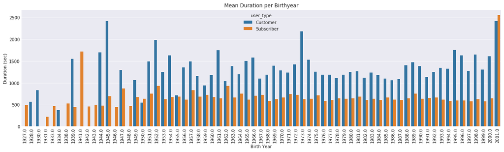

```python
# plotting the relation between customers/subscribers, birth year and the sum or all durations (sec)
plt.figure(figsize = [20, 5])

sb.barplot(data = bike, x = 'member_birth_year', y = 'duration_sec', hue = 'user_type', ci = None)
plt.xticks(rotation = 90);
plt.xlabel('Birth Year')
plt.ylabel('Duration (sec)')
plt.title('Mean Duration per Birthyear');
```

I learnt to have variables in floats instead of integers because there could be mistakes. I don't see any mistakes after the column. That's why I will show integers in x-axis to make my diagram look more professional. I won't replace the conversion, I will only use it for the chart and leave it as it is.

```python
bike['member_birth_year'] = bike['member_birth_year'].fillna(0)
```

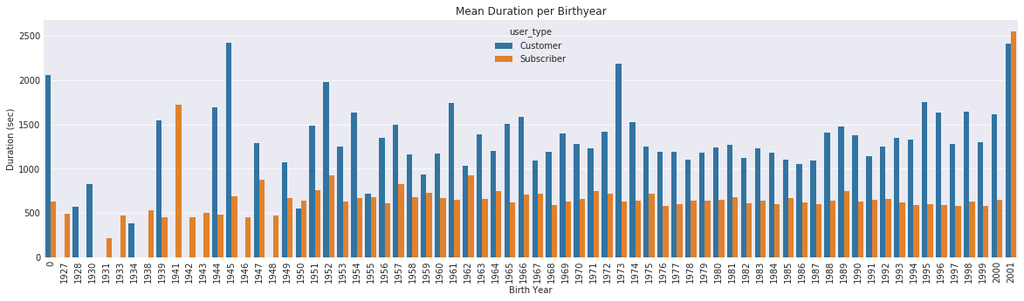

```python
plt.figure(figsize = [20, 5])

sb.barplot(data = bike, x = bike.member_birth_year.round(0).astype(int),
           y = 'duration_sec', hue = 'user_type', ci = None)
plt.xticks(rotation = 90);
plt.xlabel('Birth Year')
plt.ylabel('Duration (sec)')
plt.title('Mean Duration per Birthyear');
```

This doesn't look very bad but I prefer to limit the years a little bit. I will create columns with age stages:

- 1989-2001 birthyear = 'Young Adults' (18-30 years)
- 1959-1988 birthyear = 'Middle Age' (31-60 years)
- 1927-1958 birthyear = 'Retired' (61-92 years)

```python
conditions = [
    (bike['member_birth_year'] >= 1989) & (bike['member_birth_year'] < 2002),
    (bike['member_birth_year'] >= 1959) & (bike['member_birth_year'] < 1989),
    (bike['member_birth_year'] >= 1927) & (bike['member_birth_year'] < 1959),]
name = ['Young Adults', 'Middle Age', 'Retired']

bike['age_stage'] = np.select(conditions, name, default = 'Not Specified')
```

```python
bike.head(1)
```

|  | duration_sec | start_time | end_time | start_station_id | start_station_name | start_station_latitude | start_station_longitude | end_station_id | end_station_name | end_station_latitude | ... | member_birth_year | member_gender | bike_share_for_all_trip | start_month | start_day | end_month | end_day | start_time_hour | overnight | age_stage |
| --- | --- | --- | --- | --- | --- | --- | --- | --- | --- | --- | --- | --- | --- | --- | --- | --- | --- | --- | --- | --- | --- |
| 0 | 52185 | 2019-02-28 17:32:10.145 | 2019-03-01 08:01:55.975 | 21.0 | Montgomery St BART Station (Market St at 2nd St) | 37.789625 | -122.400811 | 13.0 | Commercial St at Montgomery St | 37.794231 | ... | 1984.0 | Male | No | 2 | Thursday | 3 | Friday | 17 | Yes | Middle Age |

1 rows × 23 columns

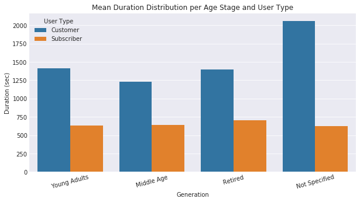

```python
plt.figure(figsize = [10, 5])
plot_order = ['Young Adults', 'Middle Age', 'Retired', 'Not Specified']

sb.barplot(data = bike, x = 'age_stage',
           y = 'duration_sec', hue = 'user_type', ci = None, order = plot_order)

plt.xticks(rotation = 15);
plt.xlabel('Generation')
plt.ylabel('Duration (sec)')
plt.title('Mean Duration Distribution per Age Stage and User Type')
plt.legend(title = 'User Type');
```

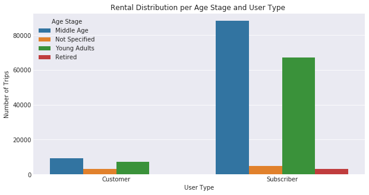

```python
plt.figure(figsize = [10, 5])
fig = sb.countplot(data = bike, x = "user_type", hue = "age_stage")
fig.set_xlabel('User Type')
fig.set_ylabel('Number of Trips')
plt.title('Rental Distribution per Age Stage and User Type ')
fig.legend(title = 'Age Stage');
```

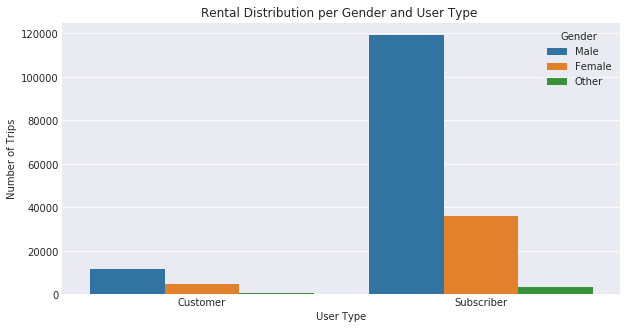

```python
plt.figure(figsize = [10, 5])
fig = sb.countplot(data = bike, x = "user_type", hue = "member_gender")
fig.set_xlabel('User Type')
fig.set_ylabel('Number of Trips')
plt.title('Rental Distribution per Gender and User Type ')
fig.legend(title = 'Gender');
```

While customer make up for longer mean in duration, subscribers have done more number of trips by a ton as we already found out in the beginning of this task.

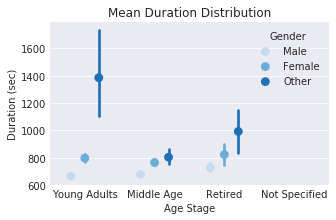

```python
fig = plt.figure(figsize = [5, 3])
ax = sb.pointplot(data = bike, x = 'age_stage', y = 'duration_sec', hue = 'member_gender',
           palette = 'Blues', linestyles = '', dodge = 0.4, order = plot_order)
plt.title('Mean Duration Distribution')
plt.ylabel('Duration (sec)')
plt.xlabel('Age Stage')
ax.legend(title = 'Gender')
plt.show();
```

I was a bit impressed by the mean of that chart. I exptected a higher mean for males and especially didn't expect other to have the highest mean. This is the magic of statistics, I guess. People like me expecting male to have a higher mean, because they rent way more bikes than femals and others together. I keep 'Not Specified' to show that this lacks data collection of the company. This isn't a data collection mistake, rather a lack of collecting data in general. There are some bike users, who don't give any personal data and the company doesn't care. I personally like it, because I'm a fan of data privacy.

```python
# checking if the mean is somewhat correct
bike.groupby('member_gender').mean()
```

| member_gender | duration_sec | start_station_id | start_station_latitude | start_station_longitude | end_station_id | end_station_latitude | end_station_longitude | bike_id | member_birth_year | start_month | end_month | start_time_hour |
| --- | --- | --- | --- | --- | --- | --- | --- | --- | --- | --- | --- | --- |
| Male | 672.639883 | 138.855535 | 37.767029 | -122.349437 | 136.300245 | 37.767241 | -122.349074 | 4507.090313 | 1984.586740 | 2.0 | 2.000077 | 13.525205 |
| Female | 779.147637 | 138.136648 | 37.780391 | -122.356852 | 136.321272 | 37.780556 | -122.356208 | 4397.185452 | 1985.811952 | 2.0 | 2.000049 | 13.216483 |
| Other | 996.589154 | 152.886725 | 37.798441 | -122.356032 | 150.640428 | 37.798309 | -122.355919 | 4542.596549 | 1983.141057 | 2.0 | 2.000548 | 13.671049 |

Now I have to find a correlation between user type, gender and age stage.

```python
bike[bike['user_type'] == "Customer"].groupby('age_stage').mean()
```

| age_stage | duration_sec | start_station_id | start_station_latitude | start_station_longitude | end_station_id | end_station_latitude | end_station_longitude | bike_id | member_birth_year | start_month | end_month | start_time_hour |
| --- | --- | --- | --- | --- | --- | --- | --- | --- | --- | --- | --- | --- |
| Middle Age | 1230.302285 | 132.296248 | 37.781055 | -122.378060 | 132.197967 | 37.781689 | -122.377325 | 4331.515632 | 1980.086136 | 2.0 | 2.000216 | 13.329991 |
| Not Specified | 2061.594069 | 128.827202 | 37.777893 | -122.376256 | 134.495209 | 37.778497 | -122.376468 | 3548.928020 | 0.000000 | 2.0 | 2.000309 | 13.837504 |
| Retired | 1396.148148 | 144.968254 | 37.781943 | -122.352576 | 154.476190 | 37.782868 | -122.352709 | 4306.243386 | 1953.814815 | 2.0 | 2.000000 | 13.137566 |
| Young Adults | 1411.276079 | 139.825354 | 37.784670 | -122.374852 | 141.656605 | 37.785113 | -122.374528 | 4390.908253 | 1993.089233 | 2.0 | 2.000140 | 13.980031 |

```python
bike[bike['user_type'] == "Subscriber"].groupby('age_stage').mean()
```

| age_stage | duration_sec | start_station_id | start_station_latitude | start_station_longitude | end_station_id | end_station_latitude | end_station_longitude | bike_id | member_birth_year | start_month | end_month | start_time_hour |
| --- | --- | --- | --- | --- | --- | --- | --- | --- | --- | --- | --- | --- |
| Middle Age | 643.315084 | 126.164835 | 37.781670 | -122.368288 | 123.513787 | 37.781830 | -122.367857 | 4487.963801 | 1979.618633 | 2.0 | 2.000057 | 13.218126 |
| Not Specified | 627.988465 | 130.546738 | 37.781185 | -122.384800 | 125.012530 | 37.781479 | -122.384345 | 4742.187947 | 0.000000 | 2.0 | 2.000199 | 13.288385 |
| Retired | 705.952541 | 129.524189 | 37.764045 | -122.340064 | 131.072872 | 37.764526 | -122.340245 | 4110.454378 | 1953.171770 | 2.0 | 2.000000 | 12.833435 |
| Young Adults | 634.002947 | 157.032914 | 37.753971 | -122.323402 | 154.031902 | 37.754105 | -122.322991 | 4523.744575 | 1993.086749 | 2.0 | 2.000089 | 13.760827 |

```python
bike_customer = bike[bike['user_type'] == "Customer"]
bike_subscriber = bike[bike['user_type'] == "Subscriber"]
```

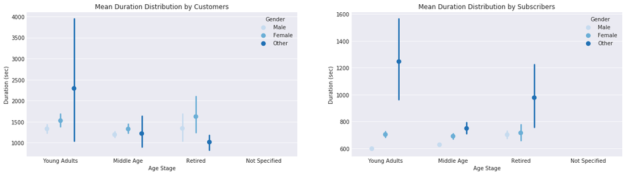

```python
# multiple plots
plt.figure(figsize = [20, 5])

# chart on left, customers
plt.subplot(1, 2, 1) # 1 row, 2 cols, subplot 1
ax = sb.pointplot(data = bike, x = bike_customer['age_stage'], y = 'duration_sec', hue = 'member_gender',
           palette = 'Blues', linestyles = '', dodge = 0.4, order = plot_order)
plt.title('Mean Duration Distribution by Customers')
plt.ylabel('Duration (sec)')
plt.xlabel('Age Stage')
ax.legend(title = 'Gender');

# chart on right, subscribers
plt.subplot(1, 2, 2) # 1 row, 2 cols, subplot 2
ax = sb.pointplot(data = bike, x = bike_subscriber['age_stage'], y = 'duration_sec', hue = 'member_gender',
           palette = 'Blues', linestyles = '', dodge = 0.4, order = plot_order)
plt.title('Mean Duration Distribution by Subscribers')
plt.ylabel('Duration (sec)')
plt.xlabel('Age Stage')
ax.legend(title = 'Gender');
```

The Plot above has one issue. The yticks differ a lot. I'll change that.

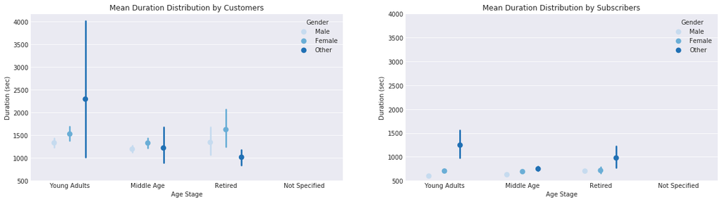

```python
# multiple plots
plt.figure(figsize = [20, 5])

# chart on left, customers
plt.subplot(1, 2, 1) # 1 row, 2 cols, subplot 1
ax = sb.pointplot(data = bike, x = bike_customer['age_stage'], y = 'duration_sec', hue = 'member_gender',
           palette = 'Blues', linestyles = '', dodge = 0.4, order = plot_order)
plt.title('Mean Duration Distribution by Customers')
plt.ylabel('Duration (sec)')
plt.xlabel('Age Stage')
ax.legend(title = 'Gender')
plt.yticks(np.arange(500, 4500, 500));

# chart on right, subscribers
plt.subplot(1, 2, 2) # 1 row, 2 cols, subplot 2
ax = sb.pointplot(data = bike, x = bike_subscriber['age_stage'], y = 'duration_sec', hue = 'member_gender',
           palette = 'Blues', linestyles = '', dodge = 0.4, order = plot_order)
plt.title('Mean Duration Distribution by Subscribers')
plt.ylabel('Duration (sec)')
plt.xlabel('Age Stage')
ax.legend(title = 'Gender')
plt.yticks(np.arange(500, 4500, 500));
```

We have already seen above that the mean for subscribers is lower. The mean is higher for 'other' in subscribers than for women which is interesting, because the ranking in the customer chart is the opposite, except young adults.

### Talk about some of the relationships you observed in this part of the investigation. Were there features that strengthened each other in terms of looking at your feature(s) of interest?

> My idea that most of the people rent the bikes for going to work or college got indeed strengthen. We've already seen above that there are way more subscribers than customers, but still I compared all my numbers with both pools - subscribers and customers. I didn't find out anything new about the age and gender distribution. Everything got sorted out in the bivariate part.

## Conclusions

I wanted to find out more about the company's customers. I assume most people do this task to just analyze when bike get rent the most, who rents it etc. This is indeed something I analyzed as well, but in my opinion you always need a target why you're doing it. A company needs data analysis to improve themselves, to get more revenue and to generate more customers. That's why I tried to find out the company's heartbeat. My first intuition were the commuters, because you use a bike either for commuting, doing sport, riding in the nature and things like these. For that I looked at the mean duration and how often a bike was rent, which days had what mean and rental distribution. Finding out that the mean was about 12 minutes was a big indicator for commuting. During the week more bike were rent but on the weekend the mean was higher. My explanation for this is, that there is less data, less rentals on weekends and most people don't have to go to work or school on weekends. So if you use a bike on weekends, it's mostly for your spare time. Of course you might commute somewhere as well like going to a friend or maybe you are one of these people like me who have to work everyday, but most people have days of. That's why the mean is higher. I analyzed the rental distribution per hour and there were two peeks, one in the morning and one in the evening which are most like to be rush hour periods. At these period people go to work or go home from work which is another indicator pro the commuter argument. When I want to find out if I only have commuters, it is also important to separate the customers and subscribers. Customers tend to rent a bike longer, because they barely use it anyways. So if they rent a bike, they will most likely use it for a longer duration because the entrance price of most bikes wouldn't make up for it. I don't want to generalize that and it's very important for me to state that this is not a generalization. It's my intuition because I know the prices in Europe. I rented bikes as well but if I was a regular user, a commuter, I would never ever rent a bike for 12 minutes. I'd rather get a taxi, depending on the country and the prices. During my exploration I've realized that I need to categorize by age as well. Going to work/school people are not really known to be retired. After age stage seperation there were enough things to analyze. Looking at the mean of subscribers from different angles and different variables like gender or age stage, really strengthen my intuition that most people rent bikes for commuting.